# Analyses exploratoire des données Lapage

## Informations préliminaires :

Toutes les données sont déjà nettoyées. Une simple vérifications des doublons sera effectuées  
Analyse des différents indicateurs de vente:

Différents indicateurs et graphiques autour du chiffre d'affaires

L’évolution dans le temps et mettre en place une décomposition en moyenne mobile pour évaluer la tendance globale

Zoom sur les références : les tops | flops, la répartition par catégorie, etc…

Informations sur les profils de nos clients, et également la répartition du chiffre d'affaires entre eux, via par exemple une courbe de Lorenz

Une analyse plus ciblée sur les clients : l’objectif est de comprendre le comportement de nos clients en ligne, pour pouvoir ensuite comparer avec la connaissance acquise via nos librairies physiques.  
5 corrélations :

le lien entre le genre d’un client et les catégories des livres achetés

le lien entre l'âge des clients et le montant total des achats

le lien entre l'âge des clients et la fréquence d’achat

le lien entre l'âge des clients et la paille du panier moyen

le lien entre l'âge des clients et la catégorie des livres achetés

## Les bases

- **I**. Importation des librairies
- **II**. Fonctions
- **III**. Importation des données

## Découverte des données

- **I**. Données clients - Customers
- **II**. Données produits - Products
- **III**. Données de ventes - Transactions

## Analyse exploratoire

- **I**. Création d'un tableau complet
- **II**. Première hypothèse
- **III**. Clés de performances (*KPI sur les données BtoC*)
  - **a**. Chiffre d'affaires
    - Évolution du chiffre d'affaires
    - Chiffre d'affaire du mois dernier
    - Évolution du nombre de clients
  - **b**. Nombre de livres vendus selon le jour
  - **c**. Nombre de livres vendus selon l'heure
  - **d**. Évolution du panier moyen
  - **e**. Évolution du nombre de sessions
  - **f**. Évolution du prix moyen du livre
- **IV**. Références (*sur les données BtoC*)
  - **a**. Top / flop
    - Bestseller (*top volume*)
    - Rentable (*top chiffre d'affaires*)
    - Flop (*volume*)
    - Flop (*chiffre d'affaires*)
    - Ventes nulles (*sur la dernière années*)
    - Répartition des ventes selon le product_id (*courbe de Lorenz, loi de Pareto, indice de Gini*)
    - Top 20% des références sur lesquelles il faut se concentrer (*78% du chiffre d'affaires*)
  - **b**. Tranche de prix des livres les plus vendus
  - **c**. Proportion de chiffre d'affaires par categories
    - Proportion du CA des catégories sur l'ensemble du temps
    - Évolution du CA des différentes catégories
  - **d**. Représentation des prix par catégories
    - Visualisation des prix par catégorie
    - Prix moyen des catégorie sur toute la période de temps
    - L'évolution du prix moyen du livre sur chaque catégorie sur toute la période de temps
- **V**. Profil clients (*BtoC*)
  - **a**. Profilage clients basique
    - Répartition du chiffre d'affaires par les clients (*courbe de Lorenz*)
    - Ratio de parité de la clientèle
    - Parité similaire sur les 3 branches (*population | CA | Nombre de commandes*) ?
    - Informations globales selon le sexe
    - Tranche d'âge qui achète le plus
    - Nombre de clients par âge
  - **b**. Segmentation RFM
    - Préparation du dataframe initial
    - R. (Récent) Création du dataframe sur les achats les plus récents
    - F. (Fréquence) Création du dataframe sur les sessions les plus fréquentes par client
    - M. (Montant) Création du dataframe de classement des plus gros chiffre d'affaires réalisé par client
    - Création du dataframe RFM
    - Ciblage des clients selon la segmentation RFM Eleven
    - Synthèse du classement RFM
- **VI**. Demandes de Julie - 5 corrélations
  - **a**. Lien entre le genre d'un client et les catégories de livres achetés
    - Test Chi2 de contingence (*test d'association entre 2 variables qualitatives*)
    - Test de Cramer-V (*connaitre l'intensité de cette association*)
  - **b**. Lien entre l'âge des clients et le montant total des achats
    - Visualisation des variables
    - Visualisation par tranches d'âges
    - Quelle loi suivent les variables
    - Test de Spearman (*test de corrélation entre 2 variables quantitatives*)
  - **c**. Lien entre l'âge des clients et la fréquence d’achat
    - Visualisation des variables
    - Test de Spearman (*test de corrélation entre 2 variables quantitatives*)
  - **d**. Lien entre l'âge des clients et la taille du panier moyen
    - Visualisation des variables
    - Test de Spearman (*test de corrélation entre 2 variables quantitatives*)
    - Nouveau test de Spearman sans le groupe de jeune (*19-32 ans*)
  - **e**. Lien entre l'âge des clients et la catégorie des livres achetés
    - Visualisation des variables
    - Test ANOVA (*test d'association entre 3 groupes d'une variables qualitatives et d'une variable quantitative*)
    - Hypothèse de validation du test
    - Indépendance des variables
    - Test de Lavene (*égalité des variances entre plusieurs groupes*)
    - Test final de Kruskal-Wallis (*test ANOVA invalidé car les variances sont inégales*)
- **VI**. Optionnel pour la présentation powerpoint

## Les bases

### Importation des librairies

```python
import pandas as pd
import numpy as np
import matplotlib.pyplot as plt
import seaborn as sns
from matplotlib.patches import Rectangle
import scipy.stats as st
import datetime as dt
from math import *
from statsmodels.formula.api import ols
import re

import warnings
warnings.simplefilter("ignore")
```

### Fonctions

```python
def regress_lin(x,y):
    """Renvoie la régression linéaire des deux variables quantitatives renseignées"""
    slope, intercept, r_value, p_value, std_er = st.linregress(x,y)

    return plt.plot(x, (slope * x + intercept), c='r')


def Ranking(df, column_critere, column_result):
    """
    ---
    Utilisation pour la segmentation RFM
    ---
    Système de ranking par rapport à 5 quintiles [0:1]

    df = le dataframe sur lequel l'on travail
    column_critere = colonne sur laquelle on se base pour la comparaison
    column_result = colonne sur laquelle on vient afficher le rang
    """
    df[column_result] = 0

    q = 0
    rank = 1

    for quintile in range(5):
        q_next = q + 0.2

        date = np.quantile(df[column_critere], q)
        date_next = np.quantile(df[column_critere], q_next)

        df.loc[(df[column_critere] >= date) & (df[column_critere] <= date_next),column_result] = rank

        rank += 1
        q += 0.2
```

### Importation des données

```python
#Import des informations clients
df_customer = pd.read_csv("BDD/customers.csv", sep=";")
```

```python
#Import des informations produits
df_product = pd.read_csv("BDD/products.csv", sep=";")
```

```python
#Import des informations de ventes
df_transaction = pd.read_csv("BDD/Transactions.csv", sep=";")
```

## Découverte des données

### Données clients - Customers

```python
df_customer.info()
```

```
<class 'pandas.core.frame.DataFrame'>
RangeIndex: 8621 entries, 0 to 8620
Data columns (total 3 columns):
 #   Column     Non-Null Count  Dtype
---  ------     --------------  -----
 0   client_id  8621 non-null   object
 1   sex        8621 non-null   object
 2   birth      8621 non-null   int64
dtypes: int64(1), object(2)
memory usage: 202.2+ KB
```

```python
#Création d'une colonne age afin de simplifier les analyses
df_customer["age"] =  2023 - df_customer["birth"]
```

```python
#Suppression de la colonne de naissance devenue inutile
df_customer.drop(columns={"birth"}, inplace=True)
```

```python
#Vérification des doublons du la clé primaire
df_customer["client_id"].duplicated().sum()
```

```
0
```

Il y a 8621 clients enregistrés

```python
#Combien de sexes différents ?
df_customer["sex"].unique()
```

```
array(['f', 'm'], dtype=object)
```

Sexes représentés : Femme ("f") & Homme ("m")

```python
df_customer.head()
```

|  | client_id | sex | age |
| --- | --- | --- | --- |
| 0 | c_4410 | f | 56 |
| 1 | c_7839 | f | 48 |
| 2 | c_1699 | f | 39 |
| 3 | c_5961 | f | 61 |
| 4 | c_5320 | m | 80 |

### Données produits - Products

```python
df_product.info()
```

```
<class 'pandas.core.frame.DataFrame'>
RangeIndex: 3286 entries, 0 to 3285
Data columns (total 3 columns):
 #   Column   Non-Null Count  Dtype
---  ------   --------------  -----
 0   id_prod  3286 non-null   object
 1   price    3286 non-null   float64
 2   categ    3286 non-null   int64
dtypes: float64(1), int64(1), object(1)
memory usage: 77.1+ KB
```

```python
#Vérification des doublons des références produits
df_product["id_prod"].duplicated().sum()
```

```
0
```

Il y a 3286 produits différents

```python
#Quelle est l'échelle du prix
df_product["price"].describe().round(2)
```

```
count    3286.00
mean       21.86
std        29.85
min         0.62
25%         6.99
50%        13.08
75%        22.99
max       300.00
Name: price, dtype: float64
```

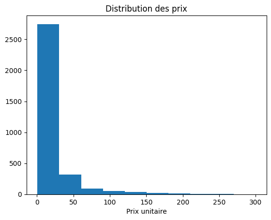

```python
plt.title("Distribution des prix")
plt.hist(df_product["price"]);

plt.xlabel("Prix unitaire")
```

```python
#Combien et quelles sont les catégories
df_product["categ"].unique()
```

```
array([0, 1, 2], dtype=int64)
```

Il y a 3 catégories: 0 , 1 et 2

### Données de ventes - Transactions

```python
df_transaction.info()
```

```
<class 'pandas.core.frame.DataFrame'>
RangeIndex: 687534 entries, 0 to 687533
Data columns (total 4 columns):
 #   Column      Non-Null Count   Dtype
---  ------      --------------   -----
 0   id_prod     687534 non-null  object
 1   date        687534 non-null  object
 2   session_id  687534 non-null  object
 3   client_id   687534 non-null  object
dtypes: object(4)
memory usage: 21.0+ MB
```

Premières notifications:

- Variable **date** au format *Object* -> passage au format *Date*
- Des dates sont erronées (format (+) de 24h -> [0:24] au lieu de [0:23]) -> constat fait après un premier essai de conversion
- Ajouter une variable mensuelle (AAAA-MM) afin de simplifier certaines analyses
- Déterminer ce que signifie **session_id** -> hypothèse: session d'achat d'un client ( 1 session -> 1 client | 1 client -> * sessions )

```python
#Correction des dates à 24h -> 00h et + 1j
for date in df_transaction["date"]:

    if (date[11] == "2") & (date[12] == "4"):
        date_split = re.split("[-: ]", date) #divise la chaine de caractères par les "-", ":", " "
        date_split[3] = "00" #changement des 24h en 00h

        #Incrémentation d'un jour
        date_split[2] = int(date_split[2]) + 1
        if date_split[2] < 10 :
            date_split[2] = "0" + str(date_split[2])
        else: date_split[2] = str(date_split[2])

        jour = ("-").join(date_split[:3])
        heure = (":").join(date_split[3:])
        date_split = jour + " " + heure

        df_transaction.loc[df_transaction["date"] == date,["date"]] = date_split
```

```python
#Correction de la variable date au bon format
df_transaction["date"] = pd.to_datetime(df_transaction["date"])

#Récupération des données necessaire de la date (tout sauf les milisecondes)
df_transaction["date"] = pd.to_datetime(df_transaction["date"].dt.strftime("%Y-%m-%d %H:%M:%S"))
```

```python
df_transaction.info()
```

```
<class 'pandas.core.frame.DataFrame'>
RangeIndex: 687534 entries, 0 to 687533
Data columns (total 4 columns):
 #   Column      Non-Null Count   Dtype
---  ------      --------------   -----
 0   id_prod     687534 non-null  object
 1   date        687534 non-null  datetime64[ns]
 2   session_id  687534 non-null  object
 3   client_id   687534 non-null  object
dtypes: datetime64[ns](1), object(3)
memory usage: 21.0+ MB
```

```python
#Création de la colonne mensuelle
df_transaction["monthly"] = pd.to_datetime(df_transaction["date"].dt.strftime('%Y-%m'))
```

```python
#Nombre de clients uniques représentés dans ce fichier
df_transaction["client_id"].unique().__len__()
```

```
8600
```

```python
#Nombre de produits uniques représentés dans ce fichier
df_transaction["id_prod"].unique().__len__()
```

```
3265
```

```python
#Nombre de sessions uniques représentés dans ce fichier
df_transaction["session_id"].unique().__len__()
```

```
345505
```

Il y a beaucoup plus de transactions que de clients.  
Est-ce que la variable "session_id" correspond à plusieurs achats d'un seul client?

```python
#Tri des sessions
df_transaction.sort_values(by="session_id", ascending=True).head(10)
```

|  | id_prod | date | session_id | client_id | monthly |
| --- | --- | --- | --- | --- | --- |
| 0 | 0_1259 | 2021-03-01 00:01:07 | s_1 | c_329 | 2021-03-01 |
| 10 | 1_635 | 2021-03-01 00:10:33 | s_10 | c_2218 | 2021-03-01 |
| 205 | 0_1451 | 2021-03-01 04:43:58 | s_100 | c_3854 | 2021-03-01 |
| 181 | 0_1030 | 2021-03-01 04:12:43 | s_100 | c_3854 | 2021-03-01 |
| 1989 | 0_1590 | 2021-03-03 02:49:03 | s_1000 | c_1014 | 2021-03-01 |
| 2021 | 0_1449 | 2021-03-03 03:18:58 | s_1000 | c_1014 | 2021-03-01 |
| 2029 | 0_1438 | 2021-03-03 03:25:12 | s_1000 | c_1014 | 2021-03-01 |
| 1984 | 0_1625 | 2021-03-03 02:38:09 | s_1000 | c_1014 | 2021-03-01 |
| 20203 | 1_395 | 2021-03-22 17:46:05 | s_10000 | c_476 | 2021-03-01 |
| 20211 | 0_1324 | 2021-03-22 17:58:20 | s_10000 | c_476 | 2021-03-01 |

Un n° de session possède bien exclusivement qu'un n° de client.

## Analyse exploratoire

### Création d'un tableau complet

```python
df_customer.info()
```

```
<class 'pandas.core.frame.DataFrame'>
RangeIndex: 8621 entries, 0 to 8620
Data columns (total 3 columns):
 #   Column     Non-Null Count  Dtype
---  ------     --------------  -----
 0   client_id  8621 non-null   object
 1   sex        8621 non-null   object
 2   age        8621 non-null   int64
dtypes: int64(1), object(2)
memory usage: 202.2+ KB
```

```python
df_product.info()
```

```
<class 'pandas.core.frame.DataFrame'>
RangeIndex: 3286 entries, 0 to 3285
Data columns (total 3 columns):
 #   Column   Non-Null Count  Dtype
---  ------   --------------  -----
 0   id_prod  3286 non-null   object
 1   price    3286 non-null   float64
 2   categ    3286 non-null   int64
dtypes: float64(1), int64(1), object(1)
memory usage: 77.1+ KB
```

```python
df_transaction.info()
```

```
<class 'pandas.core.frame.DataFrame'>
RangeIndex: 687534 entries, 0 to 687533
Data columns (total 5 columns):
 #   Column      Non-Null Count   Dtype
---  ------      --------------   -----
 0   id_prod     687534 non-null  object
 1   date        687534 non-null  datetime64[ns]
 2   session_id  687534 non-null  object
 3   client_id   687534 non-null  object
 4   monthly     687534 non-null  datetime64[ns]
dtypes: datetime64[ns](2), object(3)
memory usage: 26.2+ MB
```

```python
#Inner join entre les transactions et les produits
df_temp = df_transaction.merge(df_product, on="id_prod")
```

```python
#Récupération des données clients avec un inner join entre le future dataframe complet et les données clients
df_complet = df_temp.merge(df_customer, on="client_id")
```

```python
df_complet.head()
```

|  | id_prod | date | session_id | client_id | monthly | price | categ | sex | age |
| --- | --- | --- | --- | --- | --- | --- | --- | --- | --- |
| 0 | 0_1259 | 2021-03-01 00:01:07 | s_1 | c_329 | 2021-03-01 | 11.99 | 0 | f | 56 |
| 1 | 0_1259 | 2022-10-01 00:01:07 | s_275943 | c_329 | 2022-10-01 | 11.99 | 0 | f | 56 |
| 2 | 0_1259 | 2022-12-01 00:01:07 | s_305291 | c_329 | 2022-12-01 | 11.99 | 0 | f | 56 |
| 3 | 0_1259 | 2023-01-01 00:01:07 | s_320153 | c_329 | 2023-01-01 | 11.99 | 0 | f | 56 |
| 4 | 1_397 | 2021-11-23 18:21:56 | s_123998 | c_329 | 2021-11-01 | 18.99 | 1 | f | 56 |

```python
#Arrangement des colonnes
df_complet = df_complet[["date", "monthly", "session_id", "id_prod", "price", "categ", "client_id", "age", "sex"]]
```

```python
df_complet.info()
```

```
<class 'pandas.core.frame.DataFrame'>
RangeIndex: 687534 entries, 0 to 687533
Data columns (total 9 columns):
 #   Column      Non-Null Count   Dtype
---  ------      --------------   -----
 0   date        687534 non-null  datetime64[ns]
 1   monthly     687534 non-null  datetime64[ns]
 2   session_id  687534 non-null  object
 3   id_prod     687534 non-null  object
 4   price       687534 non-null  float64
 5   categ       687534 non-null  int64
 6   client_id   687534 non-null  object
 7   age         687534 non-null  int64
 8   sex         687534 non-null  object
dtypes: datetime64[ns](2), float64(1), int64(2), object(4)
memory usage: 47.2+ MB
```

```python
df_complet.describe()
```

|  | date | monthly | price | categ | age |
| --- | --- | --- | --- | --- | --- |
| count | 687534 | 687534 | 687534.000000 | 687534.000000 | 687534.000000 |
| mean | 2022-03-01 21:24:01.353685504 | 2022-02-14 16:12:28.721081344 | 17.493918 | 0.448789 | 45.182609 |
| min | 2021-03-01 00:01:07 | 2021-03-01 00:00:00 | 0.620000 | 0.000000 | 19.000000 |
| 25% | 2021-09-10 10:35:20 | 2021-09-01 00:00:00 | 8.990000 | 0.000000 | 36.000000 |
| 50% | 2022-02-27 06:50:25 | 2022-02-01 00:00:00 | 13.990000 | 0.000000 | 43.000000 |
| 75% | 2022-08-28 22:16:49 | 2022-08-01 00:00:00 | 19.080000 | 1.000000 | 53.000000 |
| max | 2023-02-28 23:58:30 | 2023-02-01 00:00:00 | 300.000000 | 2.000000 | 94.000000 |
| std | NaN | NaN | 18.238337 | 0.594563 | 13.607935 |

```python
#Calcul du C.A total
ca_total = df_complet["price"].sum().round(0)

ca_total
```

```
12027663.0
```

Chiffre d'affaires total : 12'027'663 €

### Première hypothèse :

- Il y a t-il des clients B2B ? (impacte important sur le C.A)

```python
#Création d'un tabeau avec les achats réalisés par chaque client
df_totalca_client = df_complet.groupby("client_id")["price"].agg(total_client="sum").reset_index()
```

```python
#Tri des paniers dans l'ordre décroissant
df_totalca_client.sort_values(by="total_client", ascending=False, inplace=True)
```

```python
df_totalca_client = df_totalca_client.reset_index()
```

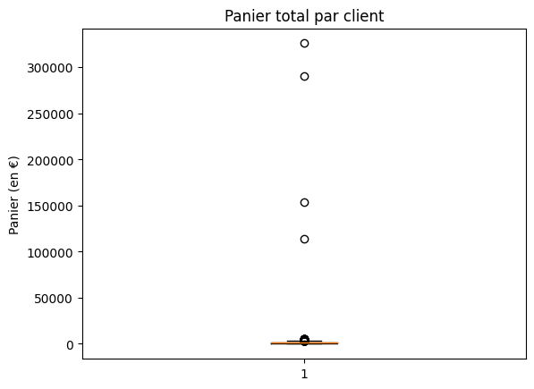

```python
plt.title("Panier total par client")
plt.boxplot(df_totalca_client["total_client"]);
plt.ylabel("Panier (en €)")
```

```python
df_totalca_client.head(6)
```

|  | index | client_id | total_client |
| --- | --- | --- | --- |
| 0 | 677 | c_1609 | 326039.89 |
| 1 | 4388 | c_4958 | 290227.03 |
| 2 | 6337 | c_6714 | 153918.60 |
| 3 | 2724 | c_3454 | 114110.57 |
| 4 | 634 | c_1570 | 5285.82 |
| 5 | 2513 | c_3263 | 5276.87 |

Il semblerai qu'il y ai plusieurs clients avec un panier total largement supérieur aux autres.  
Utiliser l'Inter Quartile Range pour cibler ces clients semblent inutiles car les 4 premiers se détachent très clairement.

```python
#Récupération de la liste des clients B2B
list_client_btob = df_totalca_client.iloc[0:4]["client_id"]

list_client_btob
```

```
0    c_1609
1    c_4958
2    c_6714
3    c_3454
Name: client_id, dtype: object
```

```python
#Création d'un data frame pour les B2B (professionnels)
df_btob = df_complet.loc[df_complet["client_id"].isin(list_client_btob)]
df_btob.info()
```

```
<class 'pandas.core.frame.DataFrame'>
Index: 46800 entries, 84 to 103787
Data columns (total 9 columns):
 #   Column      Non-Null Count  Dtype
---  ------      --------------  -----
 0   date        46800 non-null  datetime64[ns]
 1   monthly     46800 non-null  datetime64[ns]
 2   session_id  46800 non-null  object
 3   id_prod     46800 non-null  object
 4   price       46800 non-null  float64
 5   categ       46800 non-null  int64
 6   client_id   46800 non-null  object
 7   age         46800 non-null  int64
 8   sex         46800 non-null  object
dtypes: datetime64[ns](2), float64(1), int64(2), object(4)
memory usage: 3.6+ MB
```

```python
#CA total client BtoB
ca_btob = df_btob["price"].sum()
ca_btob
```

```
884296.0900000001
```

```python
#Nombre total de livre
qte_livre_btob = df_btob["price"].count()
qte_livre_btob
```

```
46800
```

```python
prix_moy = round(ca_btob / qte_livre_btob, 2)
prix_moy
```

```
18.9
```

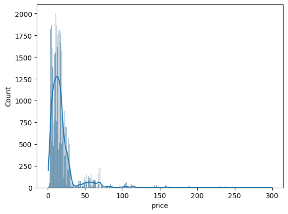

```python
#distribution des prix
sns.histplot(data=df_btob, x="price", kde=True)
```

```python
df_btob.describe()
```

|  | date | monthly | price | categ | age |
| --- | --- | --- | --- | --- | --- |
| count | 46800 | 46800 | 46800.000000 | 46800.000000 | 46800.000000 |
| mean | 2022-03-02 17:45:08.661089536 | 2022-02-15 13:11:08.307692288 | 18.895216 | 0.475577 | 44.835321 |
| min | 2021-03-01 00:07:04 | 2021-03-01 00:00:00 | 0.620000 | 0.000000 | 24.000000 |
| 25% | 2021-09-09 10:13:16 | 2021-09-01 00:00:00 | 8.990000 | 0.000000 | 43.000000 |
| 50% | 2022-03-01 16:13:04.500000 | 2022-03-01 00:00:00 | 13.990000 | 0.000000 | 43.000000 |
| 75% | 2022-08-29 16:19:28 | 2022-08-01 00:00:00 | 19.530000 | 1.000000 | 54.000000 |
| max | 2023-02-28 23:16:12 | 2023-02-01 00:00:00 | 300.000000 | 2.000000 | 55.000000 |
| std | NaN | NaN | 21.144730 | 0.636203 | 9.098456 |

```python
#Création d'un data frame représentant les clients B2C (particuliers)
df_btoc = df_complet.set_index("client_id").drop(list_client_btob).reset_index()
df_btoc.info()
```

```
<class 'pandas.core.frame.DataFrame'>
RangeIndex: 640734 entries, 0 to 640733
Data columns (total 9 columns):
 #   Column      Non-Null Count   Dtype
---  ------      --------------   -----
 0   client_id   640734 non-null  object
 1   date        640734 non-null  datetime64[ns]
 2   monthly     640734 non-null  datetime64[ns]
 3   session_id  640734 non-null  object
 4   id_prod     640734 non-null  object
 5   price       640734 non-null  float64
 6   categ       640734 non-null  int64
 7   age         640734 non-null  int64
 8   sex         640734 non-null  object
dtypes: datetime64[ns](2), float64(1), int64(2), object(4)
memory usage: 44.0+ MB
```

### Clés de performances *(KPI sur les données BtoC)* :

- Chiffre d'affaires
- Nombre de livres vendus journellement
- Nombre de livres vendus par heure
- Évolution du panier moyen
- Évolution du nombre de sessions
- Évolution du prix moyen du livre

#### Chiffre d'affaires

##### Évolution du chiffre d'affaires

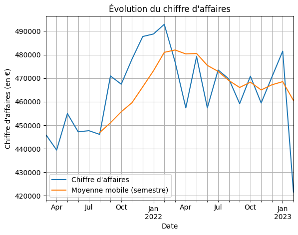

```python
#Visualisation du CA B2C
df_btoc.set_index("date")["price"].resample("m").sum().plot(label="Chiffre d'affaires");

#Visualisation de la moyenne mobile par semestre
df_btoc.set_index("monthly")["price"].resample("m").sum().rolling(6).mean().plot(label="Moyenne mobile (semestre)");

plt.title("Évolution du chiffre d'affaires");
plt.xlabel("Date")
plt.ylabel("Chiffre d'affaires (en €)")
plt.legend()
plt.grid(which="both")
```

##### Chiffre d'affaires du dernier mois

```python
#Détermination exacte du CA pour le dernier mois
df_temp = df_btoc.groupby("monthly")["price"].agg(ca_total="sum").reset_index()

ca_total_dernier_mois = df_temp.loc[df_temp["monthly"] == df_temp["monthly"].max()]["ca_total"].item()
ca_total_dernier_mois
```

```
421485.44
```

```python
#Détermination exacte du CA pour fevrier n-1
df_temp = df_btoc.groupby("monthly")["price"].agg(ca_total="sum").reset_index()

ca_total_dernier_mois_n1 = df_temp.loc[df_temp["monthly"] == "2022-02-01"]["ca_total"].item()
ca_total_dernier_mois_n1
```

```
492927.13
```

Conclusions :

- Saisonnalité cohérente pour l'achats de livres:(-) Vacances scolaires estivales | (+) Rentrée scolaire | (+) Noël & Janvier (bons cadeaux Noël utilisés)
- Forte perte en Février 2023 ~ 40'000€ (C.A estimé selon moyenne mobile: 460'000€ vs réalisé: 420'000€)

##### Évolution du nombre de client

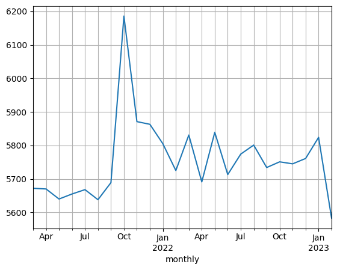

```python
df_temp = df_btoc.groupby(["monthly", "client_id"]).agg(nb_livres=("id_prod","count")).reset_index()
df_temp = df_temp.groupby("monthly").agg(nb_clients=("nb_livres","count")).reset_index()

df_temp.set_index("monthly")["nb_clients"].plot(kind="line")
plt.grid(which="both")
```

```python
nb_client_derniermois = df_temp.loc[df_temp["monthly"] == "2023-02-01"]["nb_clients"].item()
nb_client_derniermois
```

```
5583
```

```python
nb_client_derniermois_n1 = df_temp.loc[df_temp["monthly"] == "2022-02-01"]["nb_clients"].item()
nb_client_derniermois_n1
```

```
5725
```

#### Nombre de livres vendus selon le jour

```python
df_time = df_btoc
```

```python
#Création de la colonne des jours
df_time["jour"] = df_time['date'].dt.strftime("%A")
```

```python
df_time.head()
```

|  | client_id | date | monthly | session_id | id_prod | price | categ | age | sex | jour |
| --- | --- | --- | --- | --- | --- | --- | --- | --- | --- | --- |
| 0 | c_329 | 2021-03-01 00:01:07 | 2021-03-01 | s_1 | 0_1259 | 11.99 | 0 | 56 | f | Monday |
| 1 | c_329 | 2022-10-01 00:01:07 | 2022-10-01 | s_275943 | 0_1259 | 11.99 | 0 | 56 | f | Saturday |
| 2 | c_329 | 2022-12-01 00:01:07 | 2022-12-01 | s_305291 | 0_1259 | 11.99 | 0 | 56 | f | Thursday |
| 3 | c_329 | 2023-01-01 00:01:07 | 2023-01-01 | s_320153 | 0_1259 | 11.99 | 0 | 56 | f | Sunday |
| 4 | c_329 | 2021-11-23 18:21:56 | 2021-11-01 | s_123998 | 1_397 | 18.99 | 1 | 56 | f | Tuesday |

```python
df_temp = df_time.groupby("jour").agg(total_livre=("price", "count")).reset_index()
df_temp
```

|  | jour | total_livre |
| --- | --- | --- |
| 0 | Friday | 90370 |
| 1 | Monday | 92212 |
| 2 | Saturday | 90776 |
| 3 | Sunday | 92116 |
| 4 | Thursday | 90838 |
| 5 | Tuesday | 92669 |
| 6 | Wednesday | 91753 |

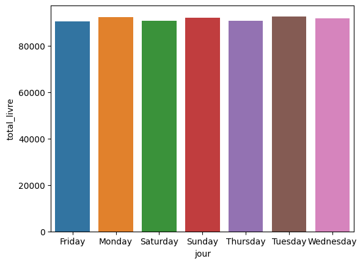

```python
sns.barplot(data=df_temp, x="jour", y="total_livre")
```

Conclusion :

- Le chiffre d'affaires est similaire pour tous les jours de la semaine.

#### Nombre de livres vendus selon l'heure

```python
df_time["heure"] = pd.to_timedelta(df_transaction['date'].dt.strftime("%H:%M:%S"))
```

```python
heures_vente = []
for date in df_time["date"]:
    date_splited = re.split("[: ]", str(date))
    heures = date_splited[1]

    heures_vente.append(heures)
```

```python
df_time["heure"] = heures_vente
```

```python
df_time
```

|  | client_id | date | monthly | session_id | id_prod | price | categ | age | sex | jour | heure |
| --- | --- | --- | --- | --- | --- | --- | --- | --- | --- | --- | --- |
| 0 | c_329 | 2021-03-01 00:01:07 | 2021-03-01 | s_1 | 0_1259 | 11.99 | 0 | 56 | f | Monday | 00 |
| 1 | c_329 | 2022-10-01 00:01:07 | 2022-10-01 | s_275943 | 0_1259 | 11.99 | 0 | 56 | f | Saturday | 00 |
| 2 | c_329 | 2022-12-01 00:01:07 | 2022-12-01 | s_305291 | 0_1259 | 11.99 | 0 | 56 | f | Thursday | 00 |
| 3 | c_329 | 2023-01-01 00:01:07 | 2023-01-01 | s_320153 | 0_1259 | 11.99 | 0 | 56 | f | Sunday | 00 |
| 4 | c_329 | 2021-11-23 18:21:56 | 2021-11-01 | s_123998 | 1_397 | 18.99 | 1 | 56 | f | Tuesday | 18 |
| ... | ... | ... | ... | ... | ... | ... | ... | ... | ... | ... | ... |
| 640729 | c_7739 | 2022-08-28 16:51:07 | 2022-08-01 | s_259828 | 2_163 | 68.99 | 2 | 26 | m | Sunday | 16 |
| 640730 | c_7739 | 2022-10-28 16:51:07 | 2022-10-01 | s_289331 | 2_163 | 68.99 | 2 | 26 | m | Friday | 16 |
| 640731 | c_712 | 2021-12-18 20:54:25 | 2021-12-01 | s_136405 | 1_64 | 19.81 | 1 | 56 | f | Saturday | 20 |
| 640732 | c_712 | 2022-10-18 20:54:25 | 2022-10-01 | s_284469 | 1_64 | 19.81 | 1 | 56 | f | Tuesday | 20 |
| 640733 | c_4478 | 2021-09-15 19:42:08 | 2021-09-01 | s_90430 | 0_1692 | 13.36 | 0 | 53 | f | Wednesday | 19 |

640734 rows × 11 columns

```python
#Création d'un dataframe pour récupérer le nombre de livres par heures et par mois
df_temp = df_time.groupby(["monthly", "heure"]).agg(nb_livres=("price","count")).reset_index()

#Création d'un dataframe récupérant le nombre de livre moyen par heures
df_temp = df_temp.groupby("heure").agg(nbmoy_livre=("nb_livres","mean")).reset_index()
df_temp.head()
```

|  | heure | nbmoy_livre |
| --- | --- | --- |
| 0 | 00 | 1108.625000 |
| 1 | 01 | 1111.583333 |
| 2 | 02 | 1120.250000 |
| 3 | 03 | 1095.541667 |
| 4 | 04 | 1093.583333 |

```python
xmax = df_temp.loc[df_temp["nbmoy_livre"] == df_temp["nbmoy_livre"].max()].index.item()
ymax = df_temp["nbmoy_livre"].max()

xmin = df_temp.loc[df_temp["nbmoy_livre"] == df_temp["nbmoy_livre"].min()].index.item()
ymin = df_temp["nbmoy_livre"].min()
```

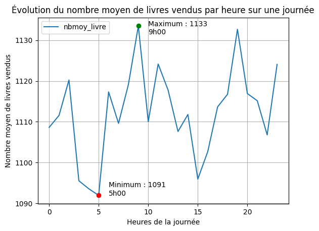

```python
sns.lineplot(data=df_temp)

plt.title("Évolution du nombre moyen de livres vendus par heure sur une journée")
plt.grid(which="both")
plt.ylabel("Nombre moyen de livres vendus")
plt.xlabel("Heures de la journée")

plt.text(xmax+1, ymax-2, "Maximum : {}\n{}h00".format(int(ymax), xmax))
plt.text(xmin+1, ymin, "Minimum : {}\n{}h00".format(int(ymin), xmin))

plt.plot(xmax,ymax,'go')
plt.plot(xmin,ymin,'ro')

plt.legend()
plt.show()
```

Conclusion :

- La quantités de livres vendus dans la journée semble assez cyclique :
  - chute vers 4h du matin
  - pique élevé vers 9h du matin
  - chute vers 15h
  - pique vers 18h
  - chute vers 22h
- Différence d'environ 40 livres vendus (1133-1091) entre l'heure avec le plus de vente (~9h00) et l'heure avec le moins de vente (~5h00)

#### Évolution du panier moyen *(attention -> 45 sessions sont sur 2 mois)*

ex: session_id(s_158089) -> 2022-02-01 00:18:14 & 2022-01-31 23:55:49

```python
#Création du data frame avec le CA par session
df_session = df_btoc.groupby(["monthly", "session_id"])["price"].agg(total_ca="sum").reset_index()
```

```python
#Affichage des sessions à cheval sur 2 mois
#df_session[df_session.duplicated(subset="session_id")]
```

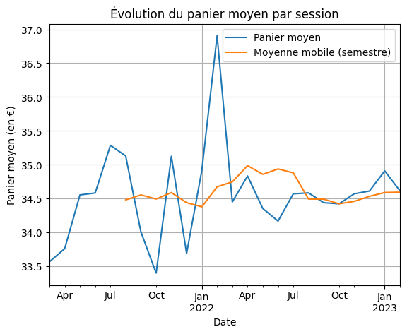

```python
#Visualisation de l'évolution du panier moyen
df_session.set_index("monthly")["total_ca"].resample("m").mean().plot(label="Panier moyen")
#Visualisation de la moyenne mobile en semestre
df_session.set_index("monthly")["total_ca"].resample("m").mean().rolling(6).mean().plot(label="Moyenne mobile (semestre)")

plt.title("Évolution du panier moyen par session")
plt.xlabel("Date")
plt.ylabel("Panier moyen (en €)")
plt.legend()
plt.grid()
```

```python
panier_moy_derniermois = df_session.loc[df_session["monthly"] == "2023-02-01"]["total_ca"].mean().item()
panier_moy_derniermois
```

```
34.61324135665599
```

```python
panier_moy_derniermois_n1 = df_session.loc[df_session["monthly"] == "2022-02-01"]["total_ca"].mean().item()
panier_moy_derniermois_n1
```

```
36.90403009657857
```

Conclusion :

- Panier moyen par session stable, notament ce dernier mois -> hypothèse: moins de sessions
- Pic important en Janvier / Février 2022 (cartes cadeaux + fond propre utilisés?)

#### Évolution du nombre de sessions

```python
#Création du data frame avec le nombre de session par mois
df_nbsession = df_btoc.groupby(["monthly", "session_id"])["price"].sum().reset_index()
df_nbsession = df_nbsession.groupby("monthly").agg(nb_session=("session_id","count")).reset_index()
```

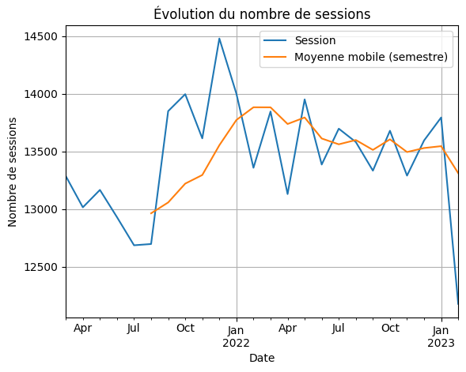

```python
#Visualisation de l'évolution du nombre de session par mois
df_nbsession.set_index("monthly")["nb_session"].plot(label="Session")
#Visualisation de la moyenne mobile semestrielle
df_nbsession.set_index("monthly")["nb_session"].rolling(6).mean().plot(label="Moyenne mobile (semestre)")

plt.title("Évolution du nombre de sessions")
plt.xlabel("Date")
plt.ylabel("Nombre de sessions")
plt.legend()
plt.grid()
```

```python
nbsession_derniermois = df_nbsession.loc[df_nbsession["monthly"] == "2023-02-01"]["nb_session"].item()
nbsession_derniermois
```

```
12177
```

```python
nbsession_derniermois_n1 = df_nbsession.loc[df_nbsession["monthly"] == "2022-02-01"]["nb_session"].item()
nbsession_derniermois_n1
```

```
13357
```

Conclusion :

- C'est le nombre de session en baisse qui est la cause de la chute du C.A en Février 2023
- Il serait interessant d'avoir les visites sans actes d'achats pour déterminer un taux de conversion

#### Évolution du prix moyen du livre

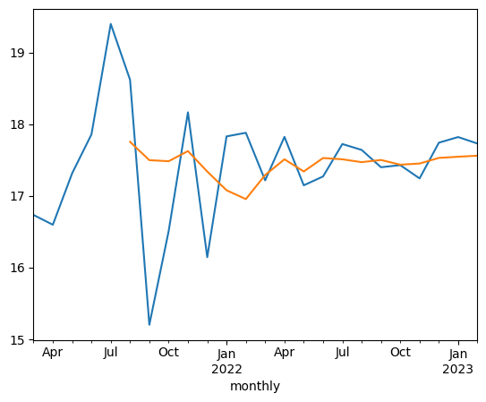

```python
df_btoc.set_index("monthly")["price"].resample("m").mean().plot()
df_btoc.set_index("monthly")["price"].resample("m").mean().rolling(6).mean().plot()
```

```python
df_prix_moy = df_btoc.groupby(["monthly"]).agg(prix_moy=("price","mean")).reset_index()
df_prix_moy
```

|  | monthly | prix_moy |
| --- | --- | --- |
| 0 | 2021-03-01 | 16.734293 |
| 1 | 2021-04-01 | 16.597577 |
| 2 | 2021-05-01 | 17.314535 |
| 3 | 2021-06-01 | 17.856944 |
| 4 | 2021-07-01 | 19.397320 |
| 5 | 2021-08-01 | 18.618339 |
| 6 | 2021-09-01 | 15.203287 |
| 7 | 2021-10-01 | 16.508220 |
| 8 | 2021-11-01 | 18.165283 |
| 9 | 2021-12-01 | 16.145505 |
| 10 | 2022-01-01 | 17.829373 |
| 11 | 2022-02-01 | 17.879761 |
| 12 | 2022-03-01 | 17.216505 |
| 13 | 2022-04-01 | 17.822833 |
| 14 | 2022-05-01 | 17.147356 |
| 15 | 2022-06-01 | 17.270697 |
| 16 | 2022-07-01 | 17.722813 |
| 17 | 2022-08-01 | 17.640754 |
| 18 | 2022-09-01 | 17.399315 |
| 19 | 2022-10-01 | 17.428574 |
| 20 | 2022-11-01 | 17.243644 |
| 21 | 2022-12-01 | 17.741687 |
| 22 | 2023-01-01 | 17.820219 |
| 23 | 2023-02-01 | 17.729586 |

```python
prixmoy_derniermois = df_prix_moy.loc[df_prix_moy["monthly"] == "2023-02-01"]["prix_moy"].item()
prixmoy_derniermois
```

```
17.729585664409203
```

```python
prixmoy_derniermois_n1 = df_prix_moy.loc[df_prix_moy["monthly"] == "2022-02-01"]["prix_moy"].item()
prixmoy_derniermois_n1
```

```
17.879760963400923
```

### Références *(sur les données BtoC)* :

- Top / Flop
- Tranche de prix des livres les plus vendus
- Proportion de CA des categories
- Représentation des prix par catégories

#### Top / Flop

```python
#Création du dataframe aggrégé sur les produits
df_temp = df_btoc.groupby("id_prod")["price"].agg(total_book="count", total_ca="sum").reset_index()
```

##### Bestseller (Top volume)

```python
df_bestseller = df_temp.sort_values("total_book", ascending=False)

df_bestseller.head(5)
```

|  | id_prod | total_book | total_ca |
| --- | --- | --- | --- |
| 2589 | 1_369 | 2205 | 52897.95 |
| 2642 | 1_417 | 2123 | 44561.77 |
| 2639 | 1_414 | 2114 | 50376.62 |
| 2731 | 1_498 | 2042 | 47721.54 |
| 2651 | 1_425 | 2026 | 34421.74 |

```python
reference_bestseller = df_bestseller.iloc[0:10,0].tolist()
reference_bestseller
```

```
['1_369',
 '1_417',
 '1_414',
 '1_498',
 '1_425',
 '1_413',
 '1_412',
 '1_407',
 '1_396',
 '1_403']
```

##### Rentable (Top chiffre d'affaires)

```python
df_rentable = df_temp.sort_values("total_ca", ascending=False)

df_rentable.head(10)
```

|  | id_prod | total_book | total_ca |
| --- | --- | --- | --- |
| 3093 | 2_159 | 624 | 91097.76 |
| 3067 | 2_135 | 920 | 63470.80 |
| 3043 | 2_112 | 870 | 58785.90 |
| 3032 | 2_102 | 941 | 55650.74 |
| 2589 | 1_369 | 2205 | 52897.95 |
| 2617 | 1_395 | 1800 | 52182.00 |
| 3149 | 2_209 | 725 | 50742.75 |
| 2639 | 1_414 | 2114 | 50376.62 |
| 2605 | 1_383 | 1716 | 49746.84 |
| 3101 | 2_166 | 210 | 48308.40 |

```python
reference_rentable = df_rentable.iloc[0:10,0].tolist()
reference_rentable
```

```
['2_159',
 '2_135',
 '2_112',
 '2_102',
 '1_369',
 '1_395',
 '2_209',
 '1_414',
 '1_383',
 '2_166']
```

##### Flop (volume)

```python
df_flop = df_temp.sort_values(["total_book", "total_ca"], ascending=True)

df_flop.head(5)
```

|  | id_prod | total_book | total_ca |
| --- | --- | --- | --- |
| 209 | 0_1191 | 1 | 0.99 |
| 594 | 0_1539 | 1 | 0.99 |
| 312 | 0_1284 | 1 | 1.38 |
| 799 | 0_1726 | 1 | 1.57 |
| 664 | 0_1601 | 1 | 1.99 |

##### Flop (chiffre d'affaires)

```python
df_inutile = df_temp.sort_values("total_ca", ascending=True)

df_inutile.head(5)
```

|  | id_prod | total_book | total_ca |
| --- | --- | --- | --- |
| 594 | 0_1539 | 1 | 0.99 |
| 209 | 0_1191 | 1 | 0.99 |
| 312 | 0_1284 | 1 | 1.38 |
| 799 | 0_1726 | 1 | 1.57 |
| 718 | 0_1653 | 2 | 1.98 |

##### Ventes nulles (*sur la dernière années*)

```python
#Récupération des références vendues sur toute la période
prod_fulltime = df_btoc["id_prod"].unique().tolist()

#Récupération des références vendues sur seulement la denrièere année
prod_last_annee = df_btoc.loc[df_btoc["monthly"] >= "2022-02-01"]["id_prod"].unique().tolist()
```

```python
ventes_nulles = list(set(prod_fulltime) - set(prod_last_annee))

len(ventes_nulles)
```

```
43
```

```python
#Création du dataframe des références invendues sur la dernière année
df_ss_vente = df_product.loc[df_product["id_prod"].isin(ventes_nulles)]
df_ss_vente.head()
```

|  | id_prod | price | categ |
| --- | --- | --- | --- |
| 114 | 0_1595 | 2.99 | 0 |
| 274 | 1_470 | 5.41 | 1 |
| 643 | 0_2263 | 32.99 | 0 |
| 674 | 0_1902 | 2.28 | 0 |
| 790 | 0_680 | 7.43 | 0 |

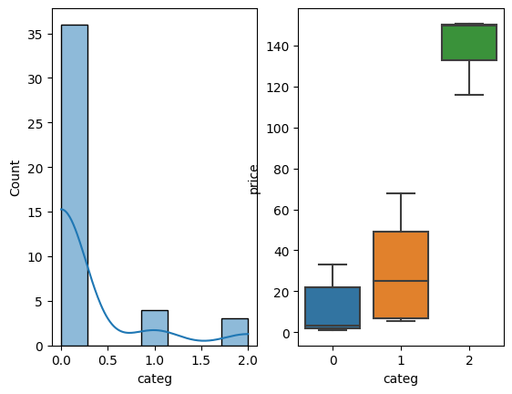

```python
plt.subplot(121)
sns.histplot(data=df_ss_vente["categ"], kde=True)

plt.subplot(122)
sns.boxplot(data=df_ss_vente, x="categ", y="price")
```

```python
df_ss_vente_T = df_ss_vente.pivot_table(index="id_prod", values="price", columns="categ").reset_index()
df_ss_vente_T.describe()
```

| categ | 0 | 1 | 2 |
| --- | --- | --- | --- |
| count | 36.000000 | 4.000000 | 3.000000 |
| mean | 11.247222 | 30.795000 | 138.816667 |
| std | 11.409900 | 30.070196 | 19.774545 |
| min | 0.990000 | 5.410000 | 115.990000 |
| 25% | 1.990000 | 6.692500 | 132.865000 |
| 50% | 2.990000 | 25.055000 | 149.740000 |
| 75% | 21.940000 | 49.157500 | 150.230000 |
| max | 32.990000 | 67.660000 | 150.720000 |

```python
df_temp_btob = df_btob.loc[(df_btob["monthly"] >= "2022-02-01") & (df_btob["id_prod"].isin(ventes_nulles))]
```

```python
df_temp = df_temp_btob.groupby(["id_prod","categ", "price"]).agg(ca_total=("price","sum"), nb_book=("price","count"))
df_temp
```

| id_prod | categ | price | ca_total | nb_book |
| --- | --- | --- | --- | --- |
| 0_1191 | 0 | 0.99 | 0.99 | 1 |
| 0_1314 | 0 | 20.63 | 61.89 | 3 |
| 0_1726 | 0 | 1.57 | 1.57 | 1 |
| 0_1820 | 0 | 22.30 | 66.90 | 3 |
| 0_419 | 0 | 20.99 | 41.98 | 2 |
| 0_680 | 0 | 7.43 | 37.15 | 5 |
| 1_470 | 1 | 5.41 | 5.41 | 1 |

```python
df_temp["ca_total"].sum()
```

```
215.89000000000001
```

##### Répartition des ventes selon le product_id (*courbe de Lorenz, loi de Pareto, indice de Gini*)

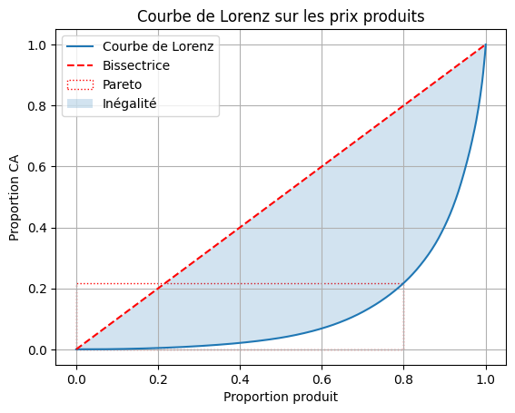

```
0.22
```

```python
chiffre_affaires = df_rentable['total_ca'].values
n = len(chiffre_affaires)

lorenz = np.cumsum(np.sort(chiffre_affaires)) / chiffre_affaires.sum() #calcul le ratio cumulé du CA des différents produits
pareto = np.quantile(lorenz, 0.8)

lorenz = np.append([0],lorenz) # La courbe de Lorenz commence à 0

#Il y a un segment de taille n pour chaque individu, plus 1 segment supplémentaire d'ordonnée 0. Le premier segment commence à 0-1/n, et le dernier termine à 1+1/n
xaxis = np.linspace(0-1/n,1+1/n,n+1)

plt.plot(xaxis, lorenz, label="Courbe de Lorenz")
plt.plot([0,1], c="r", linestyle="--", label="Bissectrice")

rect = Rectangle((0,0), 0.8,pareto, linewidth=1, edgecolor='r', facecolor='none', linestyle=":", label="Pareto")
plt.gca().add_patch(rect)

# Remplir la région entre la courbe de Lorenz et la bissectrice
plt.fill_between(xaxis, xaxis, lorenz, alpha=0.2, label='Inégalité')

plt.title("Courbe de Lorenz sur les prix produits")
plt.xlabel("Proportion produit")
plt.ylabel("Proportion CA")
plt.legend()
plt.grid()
plt.show()

pareto.round(2)
```

Loi de Pareto (20/80) largement respectée : Il y a 20% des références qui représentent 78% du C.A (1-0.22)

```python
AUC = (lorenz.sum() -lorenz[-1]/2 -lorenz[0]/2)/n # Surface sous la courbe de Lorenz. Le premier segment (lorenz[0]) est à moitié en dessous de 0, on le coupe donc en 2, on fait de même pour le dernier segment lorenz[-1] qui est à moitié au dessus de 1.
S = 0.5 - AUC # surface entre la première bissectrice et le courbe de Lorenz
gini = 2*S
gini
```

```
0.7430432755072107
```

##### Top 20% des références sur lesquelles il faut se concentrer (78% du chiffre d'affaires) : 2 options à voir!

Option 1 :

```python
#Détermine l'index qui vient au 1 quintile (df déjà trié par CA décroissant)
seuil = int(np.quantile(df_rentable.index, 0.2))
```

```python
#Récupération des références avec le plus grand CA
references_pareto = df_rentable.iloc[0:seuil]

references_pareto.info()
```

```
<class 'pandas.core.frame.DataFrame'>
Index: 652 entries, 3093 to 21
Data columns (total 3 columns):
 #   Column      Non-Null Count  Dtype
---  ------      --------------  -----
 0   id_prod     652 non-null    object
 1   total_book  652 non-null    int64
 2   total_ca    652 non-null    float64
dtypes: float64(1), int64(1), object(1)
memory usage: 20.4+ KB
```

```python
#Vérification des 20/80
ratio_ca_test = round(references_pareto["total_ca"].sum() / df_rentable["total_ca"].sum() * 100, 2)

ratio_ca_test
```

```
78.21
```

20% des références représentent bien 78.21% du chiffre d'affaires -> loi de Pareto 20/80 OK

Option 2 : (logique à revoir, ça ne fonctionne pas)

```python
#Création des colonnes de proportions pour le nombre de livres et le C.A
df_rentable["proportion_CA"] = (df_rentable["total_ca"] / df_rentable["total_ca"].sum())*100
df_rentable["proportion_book"] = (df_rentable["total_book"] / df_rentable["total_book"].sum())*100

df_rentable.head()
```

|  | id_prod | total_book | total_ca | proportion_CA | proportion_book |
| --- | --- | --- | --- | --- | --- |
| 3093 | 2_159 | 624 | 91097.76 | 0.817507 | 0.097388 |
| 3067 | 2_135 | 920 | 63470.80 | 0.569584 | 0.143585 |
| 3043 | 2_112 | 870 | 58785.90 | 0.527542 | 0.135782 |
| 3032 | 2_102 | 941 | 55650.74 | 0.499407 | 0.146863 |
| 2589 | 1_369 | 2205 | 52897.95 | 0.474703 | 0.344137 |

```python
#Tri dans l'ordre décroissant de la proportion C.A
df_rentable.sort_values("proportion_CA", ascending=False, inplace=True)
```

```python
#Création d'une colonne avec le cumul de proportion du nombre de livres
df_rentable["cum_book_proportion"] = np.cumsum(df_rentable["proportion_book"])
```

```python
#Création d'une colonne avec le cumul de proportion de C.A
df_rentable["cum_CA_proportion"] = np.cumsum(df_rentable["proportion_CA"])
```

```python
df_rentable["difference"] = df_rentable["cum_CA_proportion"] - df_rentable["cum_book_proportion"]

df_rentable = df_rentable.reset_index()
```

```python
#Récupération du seuil où l'écart en la proportion du nombre de livres et le prop du C.A est le plus grand.
df_rentable.loc[df_rentable["difference"] == df_rentable["difference"].max()]
```

|  | index | id_prod | total_book | total_ca | proportion_CA | proportion_book | cum_book_proportion | cum_CA_proportion | difference |
| --- | --- | --- | --- | --- | --- | --- | --- | --- | --- |
| 243 | 601 | 0_1545 | 673 | 12780.27 | 0.114689 | 0.105036 | 33.903461 | 51.413055 | 17.509594 |

```python
df_rentable
```

|  | index | id_prod | total_book | total_ca | proportion_CA | proportion_book | cum_book_proportion | cum_CA_proportion | difference |
| --- | --- | --- | --- | --- | --- | --- | --- | --- | --- |
| 0 | 3093 | 2_159 | 624 | 91097.76 | 0.817507 | 0.097388 | 0.097388 | 0.817507 | 7.201183e-01 |
| 1 | 3067 | 2_135 | 920 | 63470.80 | 0.569584 | 0.143585 | 0.240974 | 1.387090 | 1.146117e+00 |
| 2 | 3043 | 2_112 | 870 | 58785.90 | 0.527542 | 0.135782 | 0.376755 | 1.914632 | 1.537876e+00 |
| 3 | 3032 | 2_102 | 941 | 55650.74 | 0.499407 | 0.146863 | 0.523618 | 2.414039 | 1.890421e+00 |
| 4 | 2589 | 1_369 | 2205 | 52897.95 | 0.474703 | 0.344137 | 0.867755 | 2.888742 | 2.020987e+00 |
| ... | ... | ... | ... | ... | ... | ... | ... | ... | ... |
| 3257 | 718 | 0_1653 | 2 | 1.98 | 0.000018 | 0.000312 | 99.999376 | 99.999956 | 5.800425e-04 |
| 3258 | 799 | 0_1726 | 1 | 1.57 | 0.000014 | 0.000156 | 99.999532 | 99.999970 | 4.380606e-04 |
| 3259 | 312 | 0_1284 | 1 | 1.38 | 0.000012 | 0.000156 | 99.999688 | 99.999982 | 2.943736e-04 |
| 3260 | 209 | 0_1191 | 1 | 0.99 | 0.000009 | 0.000156 | 99.999844 | 99.999991 | 1.471868e-04 |
| 3261 | 594 | 0_1539 | 1 | 0.99 | 0.000009 | 0.000156 | 100.000000 | 100.000000 | -9.947598e-13 |

3262 rows × 9 columns

À voir, ça ne joue pas.

#### Tranche de prix des livres les plus vendus

```python
df_btoc.describe().round(2)
```

|  | date | monthly | price | categ | age |
| --- | --- | --- | --- | --- | --- |
| count | 640734 | 640734 | 640734.00 | 640734.00 | 640734.00 |
| mean | 2022-03-01 19:54:49.819372544 | 2022-02-14 14:40:32.677522688 | 17.39 | 0.45 | 45.21 |
| min | 2021-03-01 00:01:07 | 2021-03-01 00:00:00 | 0.62 | 0.00 | 19.00 |
| 25% | 2021-09-10 12:57:20.750000128 | 2021-09-01 00:00:00 | 8.99 | 0.00 | 36.00 |
| 50% | 2022-02-27 03:35:19 | 2022-02-01 00:00:00 | 13.99 | 0.00 | 44.00 |
| 75% | 2022-08-28 20:52:43.750000128 | 2022-08-01 00:00:00 | 19.04 | 1.00 | 52.00 |
| max | 2023-02-28 23:58:30 | 2023-02-01 00:00:00 | 300.00 | 2.00 | 94.00 |
| std | NaN | NaN | 18.00 | 0.59 | 13.88 |

```python
df_btoc["price"].mode()
```

```
0    15.99
Name: price, dtype: float64
```

Prix minimum: 0.62€ (certainement un prix résultant d'une réduction comme des soldes)

Prix le plus élevé: 300€

Prix moyen: 17.39€

Prix le plus acheté (mode): 15.99€

```
(0.0, 100.0)
```

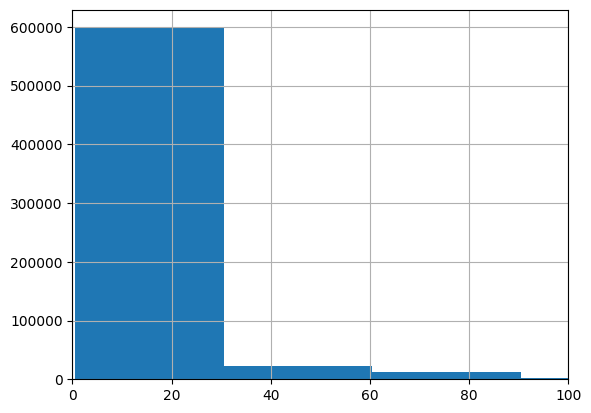

```python
df_btoc["price"].hist(bins=10)
plt.xlim(left=0, right=100)
```

Tranche de prix la plus vendue est de 0.62€ : ~ 30€ == cat 1?

```python
#Prix le plus vendu
mode_cat0 = df_btoc.loc[df_btoc["categ"] == 0]["price"].mode()
mode_cat0
```

```
0    4.99
Name: price, dtype: float64
```

```python
#Prix le plus vendu
mode_cat1 = df_btoc.loc[df_btoc["categ"] == 1]["price"].mode()
mode_cat1
```

```
0    15.99
Name: price, dtype: float64
```

```python
#Prix le plus vendu
mode_cat2 = df_btoc.loc[df_btoc["categ"] == 2]["price"].mode()
mode_cat2
```

```
0    68.99
Name: price, dtype: float64
```

#### Proportion de chiffre d'affaires par categories

##### Proportion du CA des catégories sur l'ensemble du temps

```python
first_date = df_btoc["date"].min().strftime("%m-%y")
last_date = df_btoc["date"].max().strftime("%m-%y")
```

```python
df_proportion = df_btoc.groupby("categ").agg(ca_total = ("price","sum")).reset_index()

df_proportion
```

|  | categ | ca_total |
| --- | --- | --- |
| 0 | 0 | 4119200.69 |
| 1 | 1 | 4520101.86 |
| 2 | 2 | 2504064.46 |

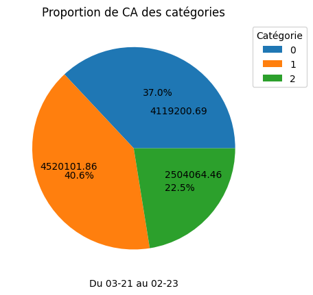

```python
plt.pie(data=df_proportion, x="ca_total", labels="ca_total", labeldistance=0.4, autopct='%1.1f%%');

plt.title("Proportion de CA des catégories")
plt.legend(df_proportion.index, title="Catégorie", bbox_to_anchor=(1.2, 1), loc='upper right');
plt.xlabel("Du {} au {}".format(first_date, last_date));
```

Conclusion: Autant de CA pour les catégories 0 et 1. Deux fois moins de CA est représenté par la catégorie 2 (la plus cher)

##### Évolution du CA des différentes catégories

```python
df_btoc.head()
```

|  | client_id | date | monthly | session_id | id_prod | price | categ | age | sex | jour | heure |
| --- | --- | --- | --- | --- | --- | --- | --- | --- | --- | --- | --- |
| 0 | c_329 | 2021-03-01 00:01:07 | 2021-03-01 | s_1 | 0_1259 | 11.99 | 0 | 56 | f | Monday | 00 |
| 1 | c_329 | 2022-10-01 00:01:07 | 2022-10-01 | s_275943 | 0_1259 | 11.99 | 0 | 56 | f | Saturday | 00 |
| 2 | c_329 | 2022-12-01 00:01:07 | 2022-12-01 | s_305291 | 0_1259 | 11.99 | 0 | 56 | f | Thursday | 00 |
| 3 | c_329 | 2023-01-01 00:01:07 | 2023-01-01 | s_320153 | 0_1259 | 11.99 | 0 | 56 | f | Sunday | 00 |
| 4 | c_329 | 2021-11-23 18:21:56 | 2021-11-01 | s_123998 | 1_397 | 18.99 | 1 | 56 | f | Tuesday | 18 |

```python
df_temp = df_btoc.groupby(["monthly","categ"]).agg(total_ca=("price","sum")).reset_index()
```

```python
df_temp = df_temp.pivot(index="monthly", columns="categ", values="total_ca")
df_temp.head()
```

| categ monthly | 0 | 1 | 2 |
| --- | --- | --- | --- |
| 2021-03-01 | 180637.95 | 174569.68 | 90711.08 |
| 2021-04-01 | 191458.18 | 145272.82 | 102606.85 |
| 2021-05-01 | 182350.51 | 155309.63 | 117227.32 |
| 2021-06-01 | 156621.73 | 177840.33 | 112640.11 |
| 2021-07-01 | 135456.27 | 176647.61 | 135489.27 |

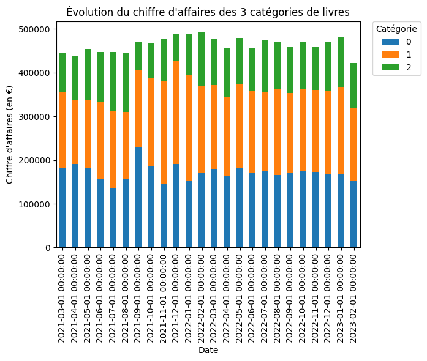

```python
df_temp.plot(kind="bar", stacked=True)

plt.title("Évolution du chiffre d'affaires des 3 catégories de livres")
plt.legend(bbox_to_anchor=(1.2, 1), loc='upper right', borderaxespad=0, title="Catégorie")

plt.xlabel("Date")
plt.ylabel("Chiffre d'affaires (en €)")
```

```python
df_temp = df_temp.reset_index()
```

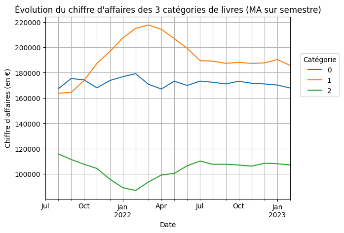

```python
df_temp.set_index("monthly").resample("m").sum().rolling(6).mean().plot()

plt.title("Évolution du chiffre d'affaires des 3 catégories de livres (MA sur semestre)")

plt.legend(bbox_to_anchor=(1.2, 0.8), loc='upper right', borderaxespad=0, title="Catégorie")
plt.grid(which="both")

plt.xlabel("Date")
plt.xlim(left=np.quantile(df_temp.monthly,0.2))#afin d'afficher seulement la portion utile
plt.ylabel("Chiffre d'affaires (en €)")
```

Conclusion: ventes de la catégorie 0 stablent, cependant quand il y a plus de C.A dans la catégorie 1, le CA de la catégorie 2 chute.

#### Représentation des prix par catégories

##### Visualisation des prix par catégorie

```python
df_produit_unique = df_btoc[["id_prod","price", "categ"]].drop_duplicates(subset="id_prod")
df_produit_unique.head()
```

|  | id_prod | price | categ |
| --- | --- | --- | --- |
| 0 | 0_1259 | 11.99 | 0 |
| 4 | 1_397 | 18.99 | 1 |
| 6 | 0_1140 | 3.73 | 0 |
| 8 | 1_451 | 20.99 | 1 |
| 9 | 1_378 | 26.61 | 1 |

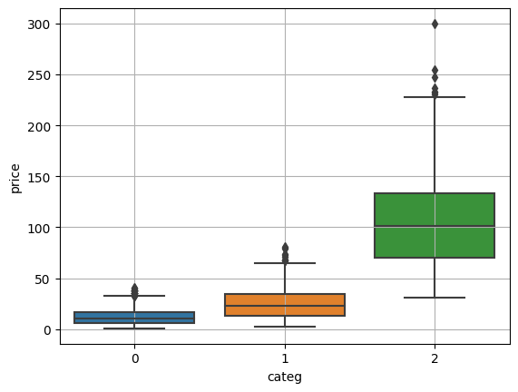

```python
sns.boxplot(data=df_produit_unique, x="categ", y="price")

plt.grid()
```

```python
df_T_produit = df_produit_unique.pivot(index="id_prod", columns="categ", values="price")
df_T_produit.describe().round(2)
```

| categ | 0 | 1 | 2 |
| --- | --- | --- | --- |
| count | 2290.00 | 737.00 | 235.00 |
| mean | 11.71 | 25.50 | 107.49 |
| std | 7.53 | 15.44 | 49.31 |
| min | 0.62 | 2.00 | 30.99 |
| 25% | 5.64 | 13.35 | 70.46 |
| 50% | 10.30 | 22.99 | 100.99 |
| 75% | 16.46 | 33.99 | 133.55 |
| max | 40.99 | 80.99 | 300.00 |

##### Prix moyen des catégorie sur toute la période de temps

```python
#Création du dataframe
df_prix_moy = df_btoc.groupby("categ").agg(prix_moyen=("price","mean")).reset_index()
df_prix_moy.head()
```

|  | categ | prix_moyen |
| --- | --- | --- |
| 0 | 0 | 10.636207 |
| 1 | 1 | 20.489571 |
| 2 | 2 | 76.231870 |

##### L'évolution du prix moyen du livre sur chaque catégorie sur toute la période de temps

```python
#Création du dataframe
df_evoprix_moy = df_btoc.groupby(["monthly","categ"]).agg(prix_moyen=("price","mean")).reset_index()
df_evoprix_moy.head()
```

|  | monthly | categ | prix_moyen |
| --- | --- | --- | --- |
| 0 | 2021-03-01 | 0 | 10.678526 |
| 1 | 2021-03-01 | 1 | 20.436628 |
| 2 | 2021-03-01 | 2 | 76.291909 |
| 3 | 2021-04-01 | 0 | 10.610040 |
| 4 | 2021-04-01 | 1 | 20.573973 |

```python
#Transposition du tableau
df_evoprix_moy = df_evoprix_moy.pivot(index="monthly", columns="categ", values="prix_moyen")
```

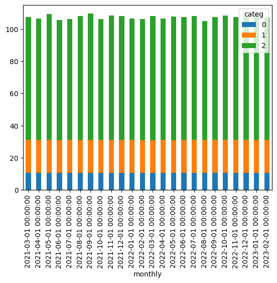

```python
df_evoprix_moy.plot(kind="bar", stacked=True)
```

```python
df_evoprix_moy.describe()
```

| categ | 0 | 1 | 2 |
| --- | --- | --- | --- |
| count | 24.000000 | 24.000000 | 24.000000 |
| mean | 10.636844 | 20.491227 | 76.280268 |
| std | 0.033196 | 0.065956 | 1.155821 |
| min | 10.560430 | 20.371095 | 73.811916 |
| 25% | 10.611399 | 20.453718 | 75.385607 |
| 50% | 10.641847 | 20.468322 | 76.371703 |
| 75% | 10.661510 | 20.522093 | 77.011563 |
| max | 10.693232 | 20.614729 | 78.308163 |

Conclusion : peu de variation de prix moyen sur les différentes catégories. Seule la catégorie 2 (la plus cher) varie de 4.5€

### Profil clients (BtoC) :

- Répartition du chiffre d'affaires par les clients (*courbe de Lorenz*)
- Ratio de parité de la clientèle
- Parité similaire sur les 3 branches (*population | CA | Nombre de commandes*) ?
- Informations globales selon le sexe
- Tranche d'âge qui achète le plus
- Nombre de clients par âge

#### Profilage clients basique

##### Répartition du chiffre d'affaires par les clients (*courbe de Lorenz*)

```python
df_CA_client = df_btoc.groupby("client_id").agg(CA_total=("price","sum")).reset_index()

df_CA_client.head()
```

|  | client_id | CA_total |
| --- | --- | --- |
| 0 | c_1 | 629.02 |
| 1 | c_10 | 1353.60 |
| 2 | c_100 | 254.85 |
| 3 | c_1000 | 2291.88 |
| 4 | c_1001 | 1823.85 |

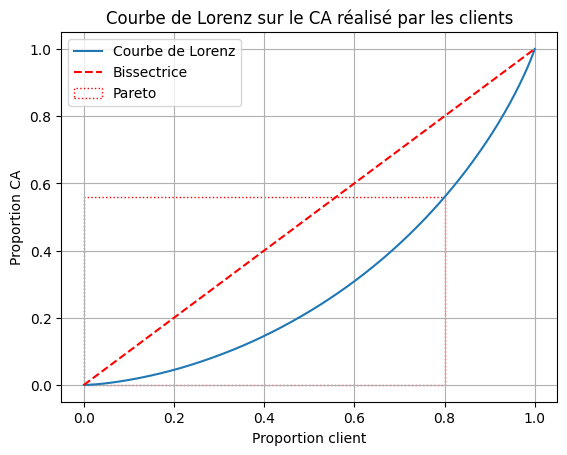

```
0.56
```

```python
chiffre_affaires = df_CA_client['CA_total'].values
n = len(chiffre_affaires)

lorenz = np.cumsum(np.sort(chiffre_affaires)) / chiffre_affaires.sum()
pareto = np.quantile(lorenz, 0.8)

lorenz = np.append([0],lorenz) # La courbe de Lorenz commence à 0

#Il y a un segment de taille n pour chaque individu, plus 1 segment supplémentaire d'ordonnée 0. Le premier segment commence à 0-1/n, et le dernier termine à 1+1/n
xaxis = np.linspace(0-1/n,1+1/n,n+1)

plt.plot(xaxis, lorenz, label="Courbe de Lorenz")
plt.plot([0,1], c="r", linestyle="--", label="Bissectrice")

rect = Rectangle((0,0), 0.8,pareto, linewidth=1, edgecolor='r', facecolor='none', linestyle=":", label="Pareto")
plt.gca().add_patch(rect)

plt.title("Courbe de Lorenz sur le CA réalisé par les clients")
plt.xlabel("Proportion client")
plt.ylabel("Proportion CA")
plt.legend()
plt.grid()
plt.show()

pareto.round(2)
```

Loi de Paréto (20/80) non-respectée : 20% des clients représentent 44% du CA (1 - 0.56)

Ou lire : 80% des clients représentent 56% de CA

##### Ratio de parité de la clientèle

```python
#Création du dataframe
df_temp = df_btoc.groupby(["client_id","session_id","sex"]).agg(CA_total=("price","sum"), book_session=("session_id", "count")).reset_index()
df_temp.head()
```

|  | client_id | session_id | sex | CA_total | book_session |
| --- | --- | --- | --- | --- | --- |
| 0 | c_1 | s_101417 | m | 15.87 | 1 |
| 1 | c_1 | s_105105 | m | 62.96 | 4 |
| 2 | c_1 | s_114737 | m | 92.62 | 5 |
| 3 | c_1 | s_120172 | m | 44.29 | 2 |
| 4 | c_1 | s_134971 | m | 10.30 | 1 |

```python
df_parite = df_temp.groupby(["client_id","sex"]).agg(ca_total=("CA_total","sum"), nb_session=("book_session","count"), livre_total=("book_session","sum")).reset_index()
df_parite.head()
```

|  | client_id | sex | ca_total | nb_session | livre_total |
| --- | --- | --- | --- | --- | --- |
| 0 | c_1 | m | 629.02 | 34 | 43 |
| 1 | c_10 | m | 1353.60 | 34 | 58 |
| 2 | c_100 | m | 254.85 | 5 | 8 |
| 3 | c_1000 | f | 2291.88 | 94 | 126 |
| 4 | c_1001 | m | 1823.85 | 47 | 103 |

```python
#Transposition des données sur le sexe
df_pariteT = df_parite.groupby("sex").agg(ca_total=("ca_total","sum"), session_total=("nb_session","sum"), livre_total=("livre_total","sum"), population=("client_id","count")).reset_index()
df_pariteT
```

|  | sex | ca_total | session_total | livre_total | population |
| --- | --- | --- | --- | --- | --- |
| 0 | f | 5796925.08 | 168546 | 333494 | 4478 |
| 1 | m | 5346441.93 | 153920 | 307240 | 4118 |

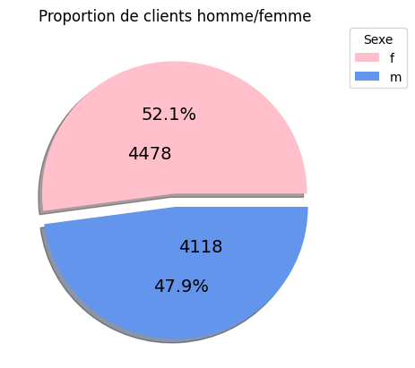

```python
#Affichage de la proportion homme/femme
explode = (0, 0.1)
plt.pie(data=df_pariteT, x="population", labels="population",
        autopct='%1.1f%%',labeldistance=0.3, explode=explode, shadow=True,
        colors=["pink","cornflowerblue"], textprops={'fontsize': 14});

plt.title("Proportion de clients homme/femme")
plt.legend(bbox_to_anchor=(1.2, 1), loc='upper right', borderaxespad=0, title="Sexe", labels=df_pariteT["sex"])
```

##### Parité similaire sur les 3 branches (*population | CA | Nombre de commandes*) ?

```python
#Transposition des données pour un graphique plus lisible
df_test = df_pariteT.set_index("sex").T
```

```python
df_test
```

| sex | f | m |
| --- | --- | --- |
| ca_total | 5796925.08 | 5346441.93 |
| session_total | 168546.00 | 153920.00 |
| livre_total | 333494.00 | 307240.00 |
| population | 4478.00 | 4118.00 |

```python
#Normalisation pour afficher un graphique avec les mêmes echelles de données
df_norm = df_test

df_norm["f"] = df_test["f"] / (df_test["f"]+df_test["m"])
df_norm["m"]= 1 - df_test["f"]

df_norm
```

| sex | f | m |
| --- | --- | --- |
| ca_total | 0.520213 | 0.479787 |
| session_total | 0.522678 | 0.477322 |
| livre_total | 0.520487 | 0.479513 |
| population | 0.520940 | 0.479060 |

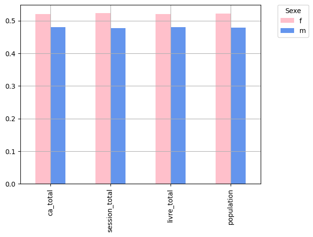

```python
df_norm.plot(kind="bar", color=["pink","cornflowerblue"])

plt.legend(bbox_to_anchor=(1.2, 1), loc='upper right', borderaxespad=0, title="Sexe")
plt.grid(which="both")
```

##### Informations globales selon le sexe

```python
df_temp = df_btoc.groupby(["client_id", "sex", "session_id"]).agg(ca_session=("price","sum")).reset_index()

df_sexe = df_temp.groupby(["client_id", "sex"]).agg(panier_moyen=("ca_session","mean")).reset_index()

df_sexe.head()
```

|  | client_id | sex | panier_moyen |
| --- | --- | --- | --- |
| 0 | c_1 | m | 18.500588 |
| 1 | c_10 | m | 39.811765 |
| 2 | c_100 | m | 50.970000 |
| 3 | c_1000 | f | 24.381702 |
| 4 | c_1001 | m | 38.805319 |

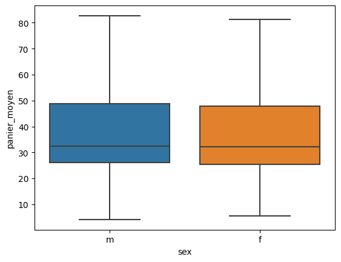

```python
sns.boxplot(data=df_sexe, x="sex", y="panier_moyen", showfliers=False)
```

```python
df_sexe_T = df_sexe.pivot_table(index="client_id",columns="sex", values="panier_moyen")
```

```python
df_sexe_T.describe()
```

| sex | f | m |
| --- | --- | --- |
| count | 4478.000000 | 4118.000000 |
| mean | 40.176306 | 40.649086 |
| std | 22.741304 | 22.788894 |
| min | 5.570000 | 4.150000 |
| 25% | 25.467425 | 25.986893 |
| 50% | 32.282341 | 32.418056 |
| 75% | 47.822981 | 48.731896 |
| max | 259.422500 | 241.160000 |

##### Tranches d'ages qui achète le plus

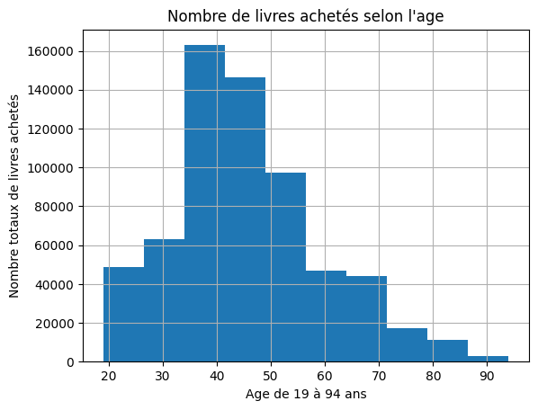

```python
df_btoc["age"].hist()

plt.title("Nombre de livres achetés selon l'age");
plt.xlabel("Age de {} à {} ans".format(df_btoc["age"].min(), df_btoc["age"].max()))
plt.ylabel("Nombre totaux de livres achetés")
```

Ce sont les 35-45 ans qui achètent le plus de livres

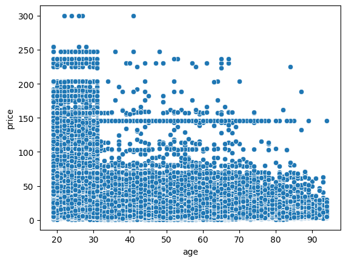

```python
sns.scatterplot(data=df_btoc[["price", "age"]], x="age", y="price")
```

Ce sont essentiellement des jeunes de 19 à 30 ans qui achètes les livres les plus chers (entre 80€ et 250€)  
Par ailleur, les livres à 150€ / unité semblent satisfaire presque tous les ages

##### Nombre de clients par âge

```python
#Création d'un dataframe avec les clients aggrégés
df_temp = df_btoc.groupby("client_id").agg(age=("age","mean"), CA_total=("price","sum")).reset_index()
```

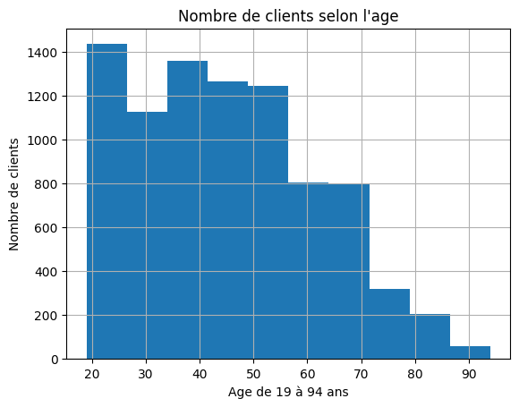

```python
df_temp["age"].hist()

plt.title("Nombre de clients selon l'age");

plt.ylabel("Nombre de clients")
plt.xlabel("Age de {} à {} ans".format(df_btoc["age"].min(), df_btoc["age"].max()))
```

```python
#Quel est l'age le plus récurrent
df_temp["age"].mode()
```

```
0    19.0
Name: age, dtype: float64
```

```python
df_temp.describe().round(0)
```

|  | age | CA_total |
| --- | --- | --- |
| count | 8596.0 | 8596.0 |
| mean | 45.0 | 1296.0 |
| std | 17.0 | 958.0 |
| min | 19.0 | 6.0 |
| 25% | 31.0 | 563.0 |
| 50% | 44.0 | 1046.0 |
| 75% | 57.0 | 1796.0 |
| max | 94.0 | 5286.0 |

Écart type de 17 ans

```python
df_temp["tranche_age"] = 0
```

```python
#Calcul du nombre de tranche d'age necessaire (arrondi à l'entier superieur)
nb_tranche = ceil((df_temp["age"].max() - df_temp["age"].min()) / df_temp["age"].std())
nb_tranche
```

```
5
```

```python
taille_tranche = ceil((df_temp["age"].max() - df_temp["age"].min()) / nb_tranche)
taille_tranche
```

```
15
```

Désignation des tranches d'age (15 ans)

19 - 34 ans

35 - 50 ans

51 - 66 ans

67 - 82 ans

83 - 98 ans

```python
#Désignation des tranches d'ages
age_mini = df_temp["age"].min()

for tranche in range(nb_tranche):
    clients_index = np.where(
                        (df_temp["age"] >= age_mini)
                        &(df_temp["age"] <= (age_mini + taille_tranche)))

    df_temp["tranche_age"].iloc[clients_index] = tranche + 1

    age_mini = age_mini + taille_tranche + 1

df_temp.head()
```

|  | client_id | age | CA_total | tranche_age |
| --- | --- | --- | --- | --- |
| 0 | c_1 | 68.0 | 629.02 | 4 |
| 1 | c_10 | 67.0 | 1353.60 | 4 |
| 2 | c_100 | 31.0 | 254.85 | 1 |
| 3 | c_1000 | 57.0 | 2291.88 | 3 |
| 4 | c_1001 | 41.0 | 1823.85 | 2 |

```python
#Dataframe utilisé dans les analyses pour Julies (plus bas)
df_tranches_ageCA = df_temp
```

```python
#Synthèse du nombre de client par tranche d'age
df_tranche = df_temp.groupby("tranche_age")["client_id"].count()
df_tranche
```

```
tranche_age
1    2707
2    2783
3    2040
4     921
5     145
Name: client_id, dtype: int64
```

```python
#Vérification du bon nombre de clients total
df_tranche.sum()
```

```
8596
```

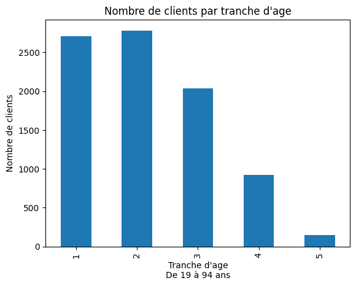

```python
df_tranche.plot(kind="bar")
plt.title("Nombre de clients par tranche d'age")
plt.ylabel("Nombre de clients")
plt.xlabel("Tranche d'age\nDe {} à {} ans".format(int(df_temp["age"].min()),int(df_temp["age"].max())));
```

#### Segmentation RFM

- Récent
- Fréquent
- Montant  
  Créer un tableau avec ces 3 colonnes par n° client pour ensuite les classer selon le Eleven RFM (11 profils client) en utilisant les quintiles

##### Préparation du dataframe initial

```python
#Création d'un data frame destiné aux classements
df_rfm = df_btoc

df_rfm["date"] = pd.to_datetime(df_rfm["date"].dt.strftime("%Y-%m-%d"))

df_rfm
```

|  | client_id | date | monthly | session_id | id_prod | price | categ | age | sex | jour | heure |
| --- | --- | --- | --- | --- | --- | --- | --- | --- | --- | --- | --- |
| 0 | c_329 | 2021-03-01 | 2021-03-01 | s_1 | 0_1259 | 11.99 | 0 | 56 | f | Monday | 00 |
| 1 | c_329 | 2022-10-01 | 2022-10-01 | s_275943 | 0_1259 | 11.99 | 0 | 56 | f | Saturday | 00 |
| 2 | c_329 | 2022-12-01 | 2022-12-01 | s_305291 | 0_1259 | 11.99 | 0 | 56 | f | Thursday | 00 |
| 3 | c_329 | 2023-01-01 | 2023-01-01 | s_320153 | 0_1259 | 11.99 | 0 | 56 | f | Sunday | 00 |
| 4 | c_329 | 2021-11-23 | 2021-11-01 | s_123998 | 1_397 | 18.99 | 1 | 56 | f | Tuesday | 18 |
| ... | ... | ... | ... | ... | ... | ... | ... | ... | ... | ... | ... |
| 640729 | c_7739 | 2022-08-28 | 2022-08-01 | s_259828 | 2_163 | 68.99 | 2 | 26 | m | Sunday | 16 |
| 640730 | c_7739 | 2022-10-28 | 2022-10-01 | s_289331 | 2_163 | 68.99 | 2 | 26 | m | Friday | 16 |
| 640731 | c_712 | 2021-12-18 | 2021-12-01 | s_136405 | 1_64 | 19.81 | 1 | 56 | f | Saturday | 20 |
| 640732 | c_712 | 2022-10-18 | 2022-10-01 | s_284469 | 1_64 | 19.81 | 1 | 56 | f | Tuesday | 20 |
| 640733 | c_4478 | 2021-09-15 | 2021-09-01 | s_90430 | 0_1692 | 13.36 | 0 | 53 | f | Wednesday | 19 |

640734 rows × 11 columns

```python
#Regroupement par session
df_rfm = df_rfm.groupby(["date","client_id","session_id"])["price"].agg(CA_session="sum").reset_index()

df_rfm
```

|  | date | client_id | session_id | CA_session |
| --- | --- | --- | --- | --- |
| 0 | 2021-03-01 | c_1031 | s_348 | 27.99 |
| 1 | 2021-03-01 | c_1052 | s_429 | 247.22 |
| 2 | 2021-03-01 | c_1074 | s_360 | 29.21 |
| 3 | 2021-03-01 | c_110 | s_244 | 21.23 |
| 4 | 2021-03-01 | c_1112 | s_54 | 31.31 |
| ... | ... | ... | ... | ... |
| 323945 | 2023-02-28 | c_945 | s_348033 | 105.98 |
| 323946 | 2023-02-28 | c_951 | s_348377 | 9.99 |
| 323947 | 2023-02-28 | c_973 | s_348099 | 74.66 |
| 323948 | 2023-02-28 | c_990 | s_348255 | 34.73 |
| 323949 | 2023-02-28 | c_990 | s_348299 | 7.99 |

323950 rows × 4 columns

##### R. (Récent) Création du dataframe sur les achats les plus récents

```python
#Récupération des sessions les plus récentes par client
df_recent = df_rfm.groupby("client_id")["date"].max().reset_index()

df_recent
```

[output not shown]

```python
#Tri dans l'ordre du plus récent au moins récent
df_recent.sort_values("date", ascending=False, inplace=True)
df_recent
```

|  | client_id | date |
| --- | --- | --- |
| 2713 | c_3445 | 2023-02-28 |
| 6034 | c_6444 | 2023-02-28 |
| 1532 | c_238 | 2023-02-28 |
| 1529 | c_2377 | 2023-02-28 |
| 2942 | c_3653 | 2023-02-28 |
| ... | ... | ... |
| 2371 | c_3136 | 2021-05-08 |
| 693 | c_1624 | 2021-04-27 |
| 4084 | c_4686 | 2021-04-07 |
| 5825 | c_6256 | 2021-04-02 |
| 5865 | c_6292 | 2021-03-09 |

8596 rows × 2 columns

```python
Ranking(df_recent,"date","R")
```

```python
df_recent
```

|  | client_id | date | R |
| --- | --- | --- | --- |
| 2713 | c_3445 | 2023-02-28 | 5 |
| 6034 | c_6444 | 2023-02-28 | 5 |
| 1532 | c_238 | 2023-02-28 | 5 |
| 1529 | c_2377 | 2023-02-28 | 5 |
| 2942 | c_3653 | 2023-02-28 | 5 |
| ... | ... | ... | ... |
| 2371 | c_3136 | 2021-05-08 | 1 |
| 693 | c_1624 | 2021-04-27 | 1 |
| 4084 | c_4686 | 2021-04-07 | 1 |
| 5825 | c_6256 | 2021-04-02 | 1 |
| 5865 | c_6292 | 2021-03-09 | 1 |

8596 rows × 3 columns

```python
df_recent["R"].unique()
```

```
array([5, 4, 3, 2, 1], dtype=int64)
```

##### F. (Fréquence) Création du dataframe sur les sessions les plus fréquentes par client

```python
#Récupération des sessions les plus fréquentes par client
df_frequence = df_rfm.groupby("client_id")["session_id"].agg(total_session = "count").reset_index()

df_frequence.head()
```

|  | client_id | total_session |
| --- | --- | --- |
| 0 | c_1 | 34 |
| 1 | c_10 | 34 |
| 2 | c_100 | 5 |
| 3 | c_1000 | 95 |
| 4 | c_1001 | 47 |

```python
#Tri dans l'ordre du plus de sessions au moins
df_frequence.sort_values("total_session", ascending=False, inplace=True)

df_frequence.head()
```

|  | client_id | total_session |
| --- | --- | --- |
| 8340 | c_8526 | 167 |
| 707 | c_1637 | 166 |
| 1405 | c_2265 | 166 |
| 8323 | c_8510 | 165 |
| 6306 | c_669 | 164 |

```python
#Création du classement par fréquence
Ranking(df_frequence, "total_session", "F")

df_frequence
```

|  | client_id | total_session | F |
| --- | --- | --- | --- |
| 8340 | c_8526 | 167 | 5 |
| 707 | c_1637 | 166 | 5 |
| 1405 | c_2265 | 166 | 5 |
| 8323 | c_8510 | 165 | 5 |
| 6306 | c_669 | 164 | 5 |
| ... | ... | ... | ... |
| 1433 | c_2290 | 1 | 1 |
| 5825 | c_6256 | 1 | 1 |
| 4042 | c_4648 | 1 | 1 |
| 2583 | c_3327 | 1 | 1 |
| 8147 | c_8351 | 1 | 1 |

8596 rows × 3 columns

##### M. (Montant) Création du dataframe de classement des plus gros chiffre d'affaires réalisé par client

```python
#Récupération du classement de chiffre d'affaires par client
df_montant = df_rfm.groupby("client_id")["CA_session"].agg(totalCA_client = "sum").reset_index()

df_montant.head()
```

|  | client_id | totalCA_client |
| --- | --- | --- |
| 0 | c_1 | 629.02 |
| 1 | c_10 | 1353.60 |
| 2 | c_100 | 254.85 |
| 3 | c_1000 | 2291.88 |
| 4 | c_1001 | 1823.85 |

```python
#Tri dans l'ordre du plus grand chiffre d'affaires au moins
df_montant.sort_values("totalCA_client", ascending=False, inplace=True)

df_montant.head()
```

|  | client_id | totalCA_client |
| --- | --- | --- |
| 634 | c_1570 | 5285.82 |
| 2512 | c_3263 | 5276.87 |
| 1267 | c_2140 | 5260.18 |
| 2107 | c_2899 | 5214.05 |
| 7002 | c_7319 | 5155.77 |

```python
#Création du classement par CA client
Ranking(df_montant, "totalCA_client", "M")

df_montant
```

|  | client_id | totalCA_client | M |
| --- | --- | --- | --- |
| 634 | c_1570 | 5285.82 | 5 |
| 2512 | c_3263 | 5276.87 | 5 |
| 1267 | c_2140 | 5260.18 | 5 |
| 2107 | c_2899 | 5214.05 | 5 |
| 7002 | c_7319 | 5155.77 | 5 |
| ... | ... | ... | ... |
| 3853 | c_4478 | 13.36 | 1 |
| 4042 | c_4648 | 11.20 | 1 |
| 7885 | c_8114 | 9.98 | 1 |
| 7914 | c_8140 | 8.30 | 1 |
| 8147 | c_8351 | 6.31 | 1 |

8596 rows × 3 columns

##### Création du dataframe RFM

```python
#Merge des 3 dataframe R(récence), F(Fréquence), M(Montant)
df_RFM = pd.merge(df_recent, df_frequence, on="client_id")
df_RFM = pd.merge(df_RFM, df_montant, on="client_id")

df_RFM
```

|  | client_id | date | R | total_session | F | totalCA_client | M |
| --- | --- | --- | --- | --- | --- | --- | --- |
| 0 | c_3445 | 2023-02-28 | 5 | 54 | 4 | 1978.80 | 4 |
| 1 | c_6444 | 2023-02-28 | 5 | 99 | 5 | 3193.62 | 5 |
| 2 | c_238 | 2023-02-28 | 5 | 84 | 5 | 2665.22 | 5 |
| 3 | c_2377 | 2023-02-28 | 5 | 71 | 5 | 1402.86 | 4 |
| 4 | c_3653 | 2023-02-28 | 5 | 61 | 5 | 1597.55 | 4 |
| ... | ... | ... | ... | ... | ... | ... | ... |
| 8591 | c_3136 | 2021-05-08 | 1 | 2 | 1 | 176.13 | 1 |
| 8592 | c_1624 | 2021-04-27 | 1 | 1 | 1 | 28.54 | 1 |
| 8593 | c_4686 | 2021-04-07 | 1 | 2 | 1 | 64.58 | 1 |
| 8594 | c_6256 | 2021-04-02 | 1 | 1 | 1 | 23.26 | 1 |
| 8595 | c_6292 | 2021-03-09 | 1 | 1 | 1 | 24.24 | 1 |

8596 rows × 7 columns

```python
#Création de la colonne pour le code RFM
df_RFM["RFM"] = df_RFM["R"].map(str) + df_RFM["F"].map(str) + df_RFM["M"].map(str)
```

```python
#Tri dans l'ordre du top clients
df_RFM.sort_values("RFM", ascending=False, inplace=True)
```

```python
df_RFM
```

|  | client_id | date | R | total_session | F | totalCA_client | M | RFM |
| --- | --- | --- | --- | --- | --- | --- | --- | --- |
| 1769 | c_4973 | 2023-02-24 | 5 | 109 | 5 | 3503.94 | 5 | 555 |
| 549 | c_247 | 2023-02-27 | 5 | 90 | 5 | 2597.22 | 5 | 555 |
| 531 | c_7403 | 2023-02-27 | 5 | 123 | 5 | 2592.73 | 5 | 555 |
| 1332 | c_6635 | 2023-02-25 | 5 | 112 | 5 | 3704.54 | 5 | 555 |
| 533 | c_7418 | 2023-02-27 | 5 | 74 | 5 | 2792.71 | 5 | 555 |
| ... | ... | ... | ... | ... | ... | ... | ... | ... |
| 7893 | c_2417 | 2022-11-08 | 1 | 12 | 1 | 196.10 | 1 | 111 |
| 7895 | c_3439 | 2022-11-08 | 1 | 5 | 1 | 102.27 | 1 | 111 |
| 7897 | c_4392 | 2022-11-08 | 1 | 10 | 1 | 317.32 | 1 | 111 |
| 7898 | c_3024 | 2022-11-08 | 1 | 4 | 1 | 179.96 | 1 | 111 |
| 8595 | c_6292 | 2021-03-09 | 1 | 1 | 1 | 24.24 | 1 | 111 |

8596 rows × 8 columns

```python
#Conversion de la colonne RFM en INT
df_RFM["RFM"] = pd.to_numeric(df_RFM["RFM"],downcast="integer")
```

##### Ciblage des clients selon la segmentation RFM Eleven

[Source avec exemple](https://www.cartelis.com/blog/segmentation-rfm-definition-calcul/)

```python
#Création des 11 catégories
noms_segments = {"1. Meilleur" : [555, 554, 544, 545, 454, 455, 445],
                    "2. Fidèle" : [543, 444, 435, 355, 354, 345, 344, 335],
                    "3. Potentiellement fidèle": [553, 551, 552, 541, 542, 533, 532, 531, 452, 451, 442, 441, 431, 453, 433, 432, 423, 353, 352, 351, 342, 341, 333, 323],
                    "4. Nouveau client" : [512, 511, 422, 421, 412, 411, 311],
                    "5. Prometteur" : [525, 524, 523, 522, 521, 515, 514, 513, 425,424, 413,414,415, 315, 314, 313],
                    "6. Standard" : [535, 534, 443, 434, 343, 334, 325, 324],
                    "7. Besoin d'attention" : [331, 321, 312, 221, 213, 231, 241, 251],
                    "8. À ne pas perdre" : [255, 254, 245, 244, 253, 252, 243, 242, 235, 234, 225, 224, 153, 152, 145, 143, 142, 135, 134, 133, 125, 124],
                    "9. À risque" : [155, 154, 144, 214,215,115, 114, 113],
                    "10. En perdition" : [332, 322, 233, 232, 223, 222, 132, 123, 122, 212, 211],
                    "11. Perdu" : [111, 112, 121, 131, 141, 151]}
```

```python
#Création de la colonne catégorie client
df_RFM["client_categ"] = "Non renseigné"
```

```python
#Assignation des segments aux clients
for client in df_RFM["client_id"]:
    rfm_client = df_RFM.loc[df_RFM["client_id"] == client,"RFM"].item()

    for segment in noms_segments.items():
        if rfm_client in segment[1]:
            df_RFM.loc[df_RFM["client_id"] == client,"client_categ"] = segment[0]
```

```python
df_RFM
```

|  | client_id | date | R | total_session | F | totalCA_client | M | RFM | client_categ |
| --- | --- | --- | --- | --- | --- | --- | --- | --- | --- |
| 1769 | c_4973 | 2023-02-24 | 5 | 109 | 5 | 3503.94 | 5 | 555 | 1. Meilleur |
| 549 | c_247 | 2023-02-27 | 5 | 90 | 5 | 2597.22 | 5 | 555 | 1. Meilleur |
| 531 | c_7403 | 2023-02-27 | 5 | 123 | 5 | 2592.73 | 5 | 555 | 1. Meilleur |
| 1332 | c_6635 | 2023-02-25 | 5 | 112 | 5 | 3704.54 | 5 | 555 | 1. Meilleur |
| 533 | c_7418 | 2023-02-27 | 5 | 74 | 5 | 2792.71 | 5 | 555 | 1. Meilleur |
| ... | ... | ... | ... | ... | ... | ... | ... | ... | ... |
| 7893 | c_2417 | 2022-11-08 | 1 | 12 | 1 | 196.10 | 1 | 111 | 11. Perdu |
| 7895 | c_3439 | 2022-11-08 | 1 | 5 | 1 | 102.27 | 1 | 111 | 11. Perdu |
| 7897 | c_4392 | 2022-11-08 | 1 | 10 | 1 | 317.32 | 1 | 111 | 11. Perdu |
| 7898 | c_3024 | 2022-11-08 | 1 | 4 | 1 | 179.96 | 1 | 111 | 11. Perdu |
| 8595 | c_6292 | 2021-03-09 | 1 | 1 | 1 | 24.24 | 1 | 111 | 11. Perdu |

8596 rows × 9 columns

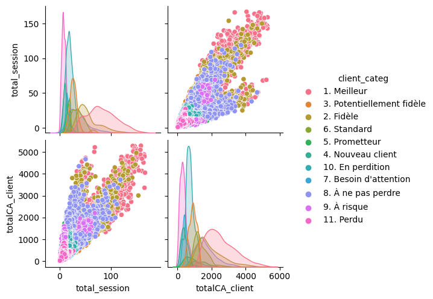

```python
sns.pairplot(df_RFM[["client_id", "total_session", "totalCA_client", "client_categ"]], hue="client_categ",)
```

##### Synthèse du classement RFM

```python
df_RFM_synthese = df_RFM.groupby("client_categ").agg(
    CA_total = ("totalCA_client","sum"),
    session_total = ("total_session","sum"),
    client_total = ("client_id","count")).reset_index()

df_RFM_synthese.sort_values("CA_total", ascending=False, inplace=True)
df_RFM_synthese
```

|  | client_categ | CA_total | session_total | client_total |
| --- | --- | --- | --- | --- |
| 0 | 1. Meilleur | 4250233.37 | 138072 | 1671 |
| 3 | 2. Fidèle | 1890145.39 | 55199 | 980 |
| 9 | 8. À ne pas perdre | 1336501.61 | 31184 | 810 |
| 1 | 10. En perdition | 1055245.36 | 28207 | 1525 |
| 7 | 6. Standard | 858618.51 | 21989 | 620 |
| 4 | 3. Potentiellement fidèle | 741971.28 | 23807 | 832 |
| 2 | 11. Perdu | 340986.04 | 9010 | 1062 |
| 6 | 5. Prometteur | 251936.16 | 4395 | 261 |
| 5 | 4. Nouveau client | 164546.84 | 4934 | 414 |
| 8 | 7. Besoin d'attention | 141262.03 | 5230 | 329 |
| 10 | 9. À risque | 111920.42 | 1923 | 92 |

### Demandes de Julie - 5 corrélations :

le lien entre le genre (**categ**) d’un client et les catégories des livres (**categ**) achetés | Test: Khi2 sur tableau de contingence (param) ou Test exact de Fisher (non-param)

le lien entre l'âge (**numeric**) des clients et le montant total (**numeric**) des achats | Test: Corrélation de Pearson (param) ou Corrélation de Spearman (non-param)

le lien entre l'âge (**numeric**) des clients et la fréquence d’achat* (**numeric**) | Test: Corrélation de Pearson (param) ou Corrélation de Spearman (non-param)

le lien entre l'âge (**numeric**) des clients et la taille du panier moyen (**numeric**) | Test: Corrélation de Pearson (param) ou Corrélation de Spearman (non-param)

le lien entre l'âge (**numeric**) des clients et la catégorie des livres achetés (**categ**) | Test: ANOVA, T-test, Kruskall-Wallis

#### - Lien entre le genre d'un client et les catégories de livres achetés

##### Test d'association entre 2 variables qualitatives (**genre** - **categ**) -> Test Chi2 de contingence :

- Conditions de validité :
  - les 2 variables sont qualitatives
  - effectifs attendus dans chaque cellule > 5 (à vérifier)
- Hypothèses :
  - nulle H0: Il **n'y a pas de lien** entre le genre et la catégorie de livres achetés (indépendance)
  - alternative H1: Il **y a un lien** entre le genre et la catégorie de livres achetés (dépendance)
- Risque accepté : 5%
- Suite à envisager -> Test de Cramer-V pour connaitre l'intensité

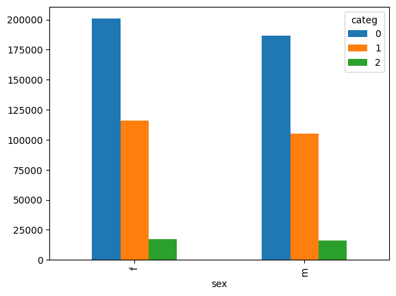

```python
#Première visualisation
genre_categ = df_btoc.pivot_table(index='sex', columns='categ', values='id_prod', aggfunc=len).reset_index()
genre_categ.plot(kind='bar', x='sex');
```

```python
#Création du tableau de contingence
X = "categ"
Y = "sex"

df_cont = df_btoc[[X,Y]].pivot_table(index=X, columns=Y, aggfunc=len, margins=True, margins_name="total")

df_cont
```

| sex categ | f | m | total |
| --- | --- | --- | --- |
| 0 | 200793 | 186488 | 387281 |
| 1 | 115721 | 104884 | 220605 |
| 2 | 16980 | 15868 | 32848 |
| total | 333494 | 307240 | 640734 |

- effectifs attendus dans chaque cellule > 5 (vérifié)

```python
#Création du dataframe de comparaison (dataframe théorique)
tx = df_cont.loc[:,["total"]] #récupère la colonne total
ty = df_cont.loc[["total"],:] #récupère la ligne total

n = len(df_btoc) #récupère le total général (toutes les lignes)

indep = tx.dot(ty) / n #produit matriciel en la colonne total et ligne total
```

```python
#Calcul des écarts entre les 2 dataframe (réel et théorique)
measure = (df_cont-indep)**2/indep #(Effectifs observés − Effectifs théoriques)² / Effectifs théoriques -> calcul des écarts de chaque cellules

xi_n = measure.sum().sum() #Valeur du Chi2 (somme de tous les écarts)

table = measure/xi_n #En divisant tous les écarts par leur somme totale -> tout est entre 0:1
```

```python
table
```

| sex categ | f | m | total |
| --- | --- | --- | --- |
| 0 | 0.133794 | 0.145227 | 0.0 |
| 1 | 0.310415 | 0.336940 | 0.0 |
| 2 | 0.035303 | 0.038320 | 0.0 |
| total | 0.000000 | 0.000000 | 0.0 |

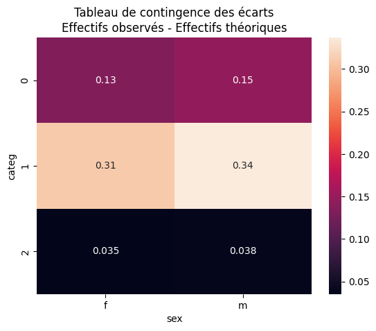

```python
#Représentation graphique des différences
sns.heatmap(table.iloc[:-1,:-1],annot=table.iloc[:-1,:-1]) #Heatmap sans la ligne "total" et la colonne "total"
plt.title("Tableau de contingence des écarts\nEffectifs observés - Effectifs théoriques");
```

```python
#Copie du dataframe sans la colonnes "total" et la ligne ""total" pour calculer la p-value
df_cont_sstotal = df_cont.drop(index="total",columns={"total"})

df_cont_sstotal
```

| sex categ | f | m |
| --- | --- | --- |
| 0 | 200793 | 186488 |
| 1 | 115721 | 104884 |
| 2 | 16980 | 15868 |

```python
#Calcul de la p-value
st_chi2, st_p, st_dof, st_exp = st.chi2_contingency(df_cont_sstotal)

st_p
```

```
1.1955928116587024e-05
```

Conclusion :

- p-value largement inférieur à 5% -> le test est significatif et **H0 est rejetée**
  - Les variables sont donc **non-indépendante** , il y a bien un lien entre le sexe et le choix de catégorie de livres

##### Passons au test de Cramer-V pour connaitre l'intensité de cette association :

- Conditions de validité :
  - les 2 variables sont qualitatives
  - avoir le résultat (la différence total au carré des cellules) du test de Chi2
- Association jugée forte si coef_cramerv > 0.6

```python
n = df_cont_sstotal.sum().sum()
min_dim = min(df_cont_sstotal.shape)-1

coef_cramerv = np.sqrt(st_chi2/(n*min_dim))

coef_cramerv
```

```
0.005948029928802536
```

Conclusion :

- Le coefficient de Cramer-V est très proche de 0
  - Il n'y a qu'une très faible association entre la variable genre et catégorie